# TSA Final project

Estimating Value-at-Risk of a Portfolio with GARCH-Family models

Afet Ibadova

07/06/2023

# Introduction

The aim of the project is to estimate Value-at-Risk (VaR) of a portfolio consisting of five financial instruments on the basis of two GARCH-family models. The portfolio will be forecasted consist of 5 financial instuments, including SP500, DAX, WIG20, KOSPI200, NIKKEI225.

The in-sample period should start on 2018-01-01. The out-of-sample period should last for 365 days and should start on 2022-01-01.

Additionally, I want to mention that, I am inspired from two article for this project:

1. Comparison of semi-parametric and benchmark value-at-risk models in several time periods with different volatility levels - Mateusz Buczyński, Marcin Chlebus - [link](https://sciendo.com/article/10.2478/fiqf-2018-0013)
2. Forecasting the volatility of stock price index: A hybrid model integrating LSTM with multiple GARCH-type models - Ha Young Kim, Chang Hyun Won - [link](https://www.sciencedirect.com/science/article/abs/pii/S0957417418301416)

## Packages and data

Lets load all needed packages

```r
library(dplyr)
library(tidyverse)
library(xts)
library(zoo)
library(fBasics)  # basicStats()
library(tseries)  # jarque.bera.test()
library(FinTS)    # ArchTest()
library(car)      # durbinWatsonTest()
library(rmgarch)
library(fGarch) # e.g. garchFit()
library(quantmod)
library(rvest)
library(lubridate)
library(graphics)
library(tictoc)

source("functions/compare_ICs_GARCH.R")
source("functions/compare_ICs_ugarchfit.R")
```

# Prepraing the data

## Fetching Data

```r
start.date <- "2000-01-01"
stop.date  <- "2023-06-07"


# Fetch data for the S&P 500
SP500 <- getSymbols("^GSPC", src = "yahoo",
                    from = start.date, to = stop.date,
                    auto.assign = FALSE)

# Fetch data for DAX from Yahoo Finance
DAX <- getSymbols("^GDAXI",
                  from = start.date, to = stop.date,
                  auto.assign = FALSE)

# Read the CSV files for Wig20, kospi200, nikkei225
wig20 <- read.csv("wig20_d.csv",
                     header = TRUE,
                     sep = ",",
                     dec = ".",
                     stringsAsFactors = F)

kospi200 <- read.csv("^kospi_d.csv",
                     header = TRUE,
                     sep = ",",
                     dec = ".",
                     stringsAsFactors = F)
nikkei225 <- read.csv("^nkx_d.csv",
                      header = TRUE,
                      sep = ",",
                      dec = ".",
                      stringsAsFactors = F)
## Print the data frames for checking
head(wig20)
```

```
##         Date    Open    High     Low   Close   Volume
## 1 2008-01-02 3453.34 3491.01 3421.25 3421.25 17396320
## 2 2008-01-03 3409.74 3442.76 3388.23 3431.72 20308433
## 3 2008-01-04 3451.54 3465.87 3374.98 3397.29 31113854
## 4 2008-01-07 3378.25 3392.42 3342.27 3345.06 26105495
## 5 2008-01-08 3362.21 3377.75 3326.10 3376.54 30261159
## 6 2008-01-09 3345.48 3345.48 3271.39 3313.38 60996205
```

```r
head(kospi200)
```

```
##         Date    Open    High     Low   Close    Volume
## 1 2008-01-02 1891.45 1892.50 1852.78 1853.45 246843984
## 2 2008-01-03 1834.43 1858.08 1821.61 1852.73 252816992
## 3 2008-01-04 1853.54 1869.76 1824.41 1863.90 298548000
## 4 2008-01-07 1815.73 1840.99 1814.35 1831.14 267838992
## 5 2008-01-08 1838.64 1840.62 1818.68 1826.23 295928992
## 6 2008-01-09 1802.06 1844.47 1794.15 1844.47 277192992
```

```r
head(nikkei225)
```

```
##         Date     Open     High      Low    Close     Volume
## 1 2008-01-04 15155.73 15156.66 14542.58 14691.41  917420864
## 2 2008-01-07 14549.37 14667.84 14438.61 14500.54 1301750784
## 3 2008-01-08 14429.29 14547.79 14365.86 14528.66 1358202880
## 4 2008-01-09 14364.71 14602.65 14271.57 14599.16 1437460864
## 5 2008-01-10 14546.32 14584.73 14388.11 14388.11 1203243776
## 6 2008-01-11 14419.42 14447.49 14096.54 14110.79 1622568576
```

```r
head(SP500)
```

```
##            GSPC.Open GSPC.High GSPC.Low GSPC.Close GSPC.Volume GSPC.Adjusted
## 2000-01-03   1469.25   1478.00  1438.36    1455.22   931800000       1455.22
## 2000-01-04   1455.22   1455.22  1397.43    1399.42  1009000000       1399.42
## 2000-01-05   1399.42   1413.27  1377.68    1402.11  1085500000       1402.11
## 2000-01-06   1402.11   1411.90  1392.10    1403.45  1092300000       1403.45
## 2000-01-07   1403.45   1441.47  1400.73    1441.47  1225200000       1441.47
## 2000-01-10   1441.47   1464.36  1441.47    1457.60  1064800000       1457.60
```

```r
head(DAX)
```

```
##            GDAXI.Open GDAXI.High GDAXI.Low GDAXI.Close GDAXI.Volume
## 2000-01-03    6961.72    7159.33   6720.87     6750.76     43072500
## 2000-01-04    6747.24    6755.36   6510.46     6586.95     46678400
## 2000-01-05    6585.85    6585.85   6388.91     6502.07     52682800
## 2000-01-06    6501.45    6539.31   6402.63     6474.92     41180600
## 2000-01-07    6489.94    6791.53   6470.14     6780.96     56058900
## 2000-01-10    6785.47    6975.26   6785.47     6925.52     42006200
##            GDAXI.Adjusted
## 2000-01-03        6750.76
## 2000-01-04        6586.95
## 2000-01-05        6502.07
## 2000-01-06        6474.92
## 2000-01-07        6780.96
## 2000-01-10        6925.52
```

```r
str(wig20)
```

```
## 'data.frame':    3861 obs. of  6 variables:
##  $ Date  : chr  "2008-01-02" "2008-01-03" "2008-01-04" "2008-01-07" ...
##  $ Open  : num  3453 3410 3452 3378 3362 ...
##  $ High  : num  3491 3443 3466 3392 3378 ...
##  $ Low   : num  3421 3388 3375 3342 3326 ...
##  $ Close : num  3421 3432 3397 3345 3377 ...
##  $ Volume: num  17396320 20308433 31113854 26105495 30261159 ...
```

```r
str(SP500)
```

```
## An xts object on 2000-01-03 / 2023-06-06 containing:
##   Data:    double [5894, 6]
##   Columns: GSPC.Open, GSPC.High, GSPC.Low, GSPC.Close, GSPC.Volume ... with 1 more column
##   Index:   Date [5894] (TZ: "UTC")
##   xts Attributes:
##     $ src    : chr "yahoo"
##     $ updated: POSIXct[1:1], format: "2023-06-10 02:01:10"
```

```r
str(DAX)
```

```
## An xts object on 2000-01-03 / 2023-06-06 containing:
##   Data:    double [5991, 6]
##   Columns: GDAXI.Open, GDAXI.High, GDAXI.Low, GDAXI.Close, GDAXI.Volume ... with 1 more column
##   Index:   Date [5991] (TZ: "UTC")
##   xts Attributes:
##     $ src    : chr "yahoo"
##     $ updated: POSIXct[1:1], format: "2023-06-10 02:01:11"
```

## Cleaning data

```r
## change date as row index
wig20 <- xts(wig20[, -1],
             order.by = as.Date(wig20$Date))
kospi200 <- xts(kospi200[, -1],
                order.by = as.Date(kospi200$Date))
nikkei225 <- xts(nikkei225[, -1],
                 order.by = as.Date(nikkei225$Date))

head(wig20)
```

```
##               Open    High     Low   Close   Volume
## 2008-01-02 3453.34 3491.01 3421.25 3421.25 17396320
## 2008-01-03 3409.74 3442.76 3388.23 3431.72 20308433
## 2008-01-04 3451.54 3465.87 3374.98 3397.29 31113854
## 2008-01-07 3378.25 3392.42 3342.27 3345.06 26105495
## 2008-01-08 3362.21 3377.75 3326.10 3376.54 30261159
## 2008-01-09 3345.48 3345.48 3271.39 3313.38 60996205
```

Let’s select only close values:

```r
## select only close values for all indexes
SP500 <- SP500[, 4]
names(SP500) <- "SP500"

wig20 <- wig20[, 4]
names(wig20) <- c("WIG20")

kospi200 <- kospi200[, 4]
names(kospi200) <- c("KOSPI200")

nikkei225 <- nikkei225[, 4]
names(nikkei225) <- c("NKK225")

DAX <- DAX[, 4]
names(DAX) <- c("DAX")
```

Create portfolio with 5 index

```r
portfolio <- SP500
portfolio$DAX <-DAX$DAX
portfolio$WIG20 <-wig20$WIG20
portfolio$KOSPI200 <- kospi200$KOSPI200
portfolio$NKK225<- nikkei225$NKK225

head(portfolio)
```

```
##              SP500     DAX WIG20 KOSPI200 NKK225
## 2000-01-03 1455.22 6750.76    NA       NA     NA
## 2000-01-04 1399.42 6586.95    NA       NA     NA
## 2000-01-05 1402.11 6502.07    NA       NA     NA
## 2000-01-06 1403.45 6474.92    NA       NA     NA
## 2000-01-07 1441.47 6780.96    NA       NA     NA
## 2000-01-10 1457.60 6925.52    NA       NA     NA
```

## Missing Values

Check the missing values

```r
any(is.na(portfolio))
```

```
## [1] TRUE
```

I have missing values, because my data start is different for different variables, that’s why limit start time from 2018

```r
portfolio <- portfolio["2018/", ]
tail (portfolio)
```

```
##              SP500      DAX   WIG20 KOSPI200   NKK225
## 2023-05-31 4179.83 15664.02 1894.48  2577.12 30887.88
## 2023-06-01 4221.02 15853.66 1946.21  2569.17 31148.01
## 2023-06-02 4282.37 16051.23 2018.09  2601.36 31524.22
## 2023-06-05 4273.79 15963.89 2020.07  2615.41 32217.43
## 2023-06-06 4283.85 15992.44 2053.44       NA 32506.78
## 2023-06-07      NA       NA 2036.31  2615.98 31913.74
```

```r
head(portfolio)
```

```
##              SP500      DAX   WIG20 KOSPI200   NKK225
## 2018-01-02 2695.81 12871.39      NA  2479.65       NA
## 2018-01-03 2713.06 12978.21 2463.25  2486.35       NA
## 2018-01-04 2723.99 13167.89 2533.17  2466.46 23506.33
## 2018-01-05 2743.15 13319.64 2529.55  2497.52 23714.53
## 2018-01-08 2747.71 13367.78 2548.61  2513.28       NA
## 2018-01-09 2751.29 13385.59 2528.38  2510.23 23849.99
```

After limiting the timeframe, I have missing values, still… I assume that these missing values exist because of non-work days. The main reason is thedifferences of public holidays across the countries. Let’s fill the null values with the previous values, assuming that if it is non-work days, the price doesn’t change.

```r
portfolio <- na.locf(portfolio)
##Check
any(is.na(portfolio))
```

```
## [1] TRUE
```

I have missing values, let’s check the head of portfolio

```r
head(portfolio)
```

```
##              SP500      DAX   WIG20 KOSPI200   NKK225
## 2018-01-02 2695.81 12871.39      NA  2479.65       NA
## 2018-01-03 2713.06 12978.21 2463.25  2486.35       NA
## 2018-01-04 2723.99 13167.89 2533.17  2466.46 23506.33
## 2018-01-05 2743.15 13319.64 2529.55  2497.52 23714.53
## 2018-01-08 2747.71 13367.78 2548.61  2513.28 23714.53
## 2018-01-09 2751.29 13385.59 2528.38  2510.23 23849.99
```

There is null values at the begining of dataset, that’s why na.locf function wasn’t fill them. Let’s omit these missing values

```r
portfolio <- na.omit(portfolio)
##Check
any(is.na(portfolio))
```

```
## [1] FALSE
```

```r
head(portfolio)
```

```
##              SP500      DAX   WIG20 KOSPI200   NKK225
## 2018-01-04 2723.99 13167.89 2533.17  2466.46 23506.33
## 2018-01-05 2743.15 13319.64 2529.55  2497.52 23714.53
## 2018-01-08 2747.71 13367.78 2548.61  2513.28 23714.53
## 2018-01-09 2751.29 13385.59 2528.38  2510.23 23849.99
## 2018-01-10 2748.23 13281.34 2511.27  2499.75 23788.20
## 2018-01-11 2767.56 13202.90 2534.56  2487.91 23710.43
```

```r
tail(portfolio)
```

```
##              SP500      DAX   WIG20 KOSPI200   NKK225
## 2023-05-31 4179.83 15664.02 1894.48  2577.12 30887.88
## 2023-06-01 4221.02 15853.66 1946.21  2569.17 31148.01
## 2023-06-02 4282.37 16051.23 2018.09  2601.36 31524.22
## 2023-06-05 4273.79 15963.89 2020.07  2615.41 32217.43
## 2023-06-06 4283.85 15992.44 2053.44  2615.41 32506.78
## 2023-06-07 4283.85 15992.44 2036.31  2615.98 31913.74
```

All Missing values are cleaned. Let’s continue 🥳

## Adding log return of index seperatedly and applying weight

```r
portfolio$SP500_r <- 0.2 * diff.xts(log(portfolio$SP500))

portfolio$DAX_r <- 0.2 * diff.xts(log(portfolio$DAX))

portfolio$WIG20_r <- 0.2 * diff.xts(log(portfolio$WIG20))

portfolio$KOSPI_r <- 0.2 * diff.xts(log(portfolio$KOSPI200))

portfolio$NKK225_r <- 0.2 * diff.xts(log(portfolio$NKK225))


head(portfolio)
```

```
##              SP500      DAX   WIG20 KOSPI200   NKK225       SP500_r
## 2018-01-04 2723.99 13167.89 2533.17  2466.46 23506.33            NA
## 2018-01-05 2743.15 13319.64 2529.55  2497.52 23714.53  0.0014018292
## 2018-01-08 2747.71 13367.78 2548.61  2513.28 23714.53  0.0003321928
## 2018-01-09 2751.29 13385.59 2528.38  2510.23 23849.99  0.0002604167
## 2018-01-10 2748.23 13281.34 2511.27  2499.75 23788.20 -0.0002225692
## 2018-01-11 2767.56 13202.90 2534.56  2487.91 23710.43  0.0014018052
##                    DAX_r       WIG20_r       KOSPI_r      NKK225_r
## 2018-01-04            NA            NA            NA            NA
## 2018-01-05  0.0022916695 -0.0002860123  0.0025028631  0.0017636388
## 2018-01-08  0.0007215486  0.0015013382  0.0012580867  0.0000000000
## 2018-01-09  0.0002662778 -0.0015938662 -0.0002428581  0.0011391715
## 2018-01-10 -0.0015637425 -0.0013580360 -0.0008367311 -0.0005188277
## 2018-01-11 -0.0011846998  0.0018462901 -0.0009495453 -0.0006549247
```

Creating of all indexes log returns all together

```r
portfolio$PORTFOLIO_r <- rowSums(portfolio[ , c("SP500_r", "DAX_r", "KOSPI_r", "WIG20_r", "NKK225_r")])

head(portfolio)
```

```
##              SP500      DAX   WIG20 KOSPI200   NKK225       SP500_r
## 2018-01-04 2723.99 13167.89 2533.17  2466.46 23506.33            NA
## 2018-01-05 2743.15 13319.64 2529.55  2497.52 23714.53  0.0014018292
## 2018-01-08 2747.71 13367.78 2548.61  2513.28 23714.53  0.0003321928
## 2018-01-09 2751.29 13385.59 2528.38  2510.23 23849.99  0.0002604167
## 2018-01-10 2748.23 13281.34 2511.27  2499.75 23788.20 -0.0002225692
## 2018-01-11 2767.56 13202.90 2534.56  2487.91 23710.43  0.0014018052
##                    DAX_r       WIG20_r       KOSPI_r      NKK225_r
## 2018-01-04            NA            NA            NA            NA
## 2018-01-05  0.0022916695 -0.0002860123  0.0025028631  0.0017636388
## 2018-01-08  0.0007215486  0.0015013382  0.0012580867  0.0000000000
## 2018-01-09  0.0002662778 -0.0015938662 -0.0002428581  0.0011391715
## 2018-01-10 -0.0015637425 -0.0013580360 -0.0008367311 -0.0005188277
## 2018-01-11 -0.0011846998  0.0018462901 -0.0009495453 -0.0006549247
##              PORTFOLIO_r
## 2018-01-04            NA
## 2018-01-05  0.0076739882
## 2018-01-08  0.0038131663
## 2018-01-09 -0.0001708583
## 2018-01-10 -0.0044999066
## 2018-01-11  0.0004589255
```

I have missing values in the first row because of the diff function, let’s omit the first row

```r
portfolio <- na.omit(portfolio)
head(portfolio)
```

```
##              SP500      DAX   WIG20 KOSPI200   NKK225       SP500_r
## 2018-01-05 2743.15 13319.64 2529.55  2497.52 23714.53  0.0014018292
## 2018-01-08 2747.71 13367.78 2548.61  2513.28 23714.53  0.0003321928
## 2018-01-09 2751.29 13385.59 2528.38  2510.23 23849.99  0.0002604167
## 2018-01-10 2748.23 13281.34 2511.27  2499.75 23788.20 -0.0002225692
## 2018-01-11 2767.56 13202.90 2534.56  2487.91 23710.43  0.0014018052
## 2018-01-12 2786.24 13245.03 2539.29  2496.42 23653.82  0.0013453853
##                    DAX_r       WIG20_r       KOSPI_r      NKK225_r
## 2018-01-05  0.0022916695 -0.0002860123  0.0025028631  0.0017636388
## 2018-01-08  0.0007215486  0.0015013382  0.0012580867  0.0000000000
## 2018-01-09  0.0002662778 -0.0015938662 -0.0002428581  0.0011391715
## 2018-01-10 -0.0015637425 -0.0013580360 -0.0008367311 -0.0005188277
## 2018-01-11 -0.0011846998  0.0018462901 -0.0009495453 -0.0006549247
## 2018-01-12  0.0006371753  0.0003728925  0.0006829410 -0.0004780823
##              PORTFOLIO_r
## 2018-01-05  0.0076739882
## 2018-01-08  0.0038131663
## 2018-01-09 -0.0001708583
## 2018-01-10 -0.0044999066
## 2018-01-11  0.0004589255
## 2018-01-12  0.0025603117
```

```r
any(is.na(portfolio))
```

```
## [1] FALSE
```

# Volatility Modelling - stylized facts

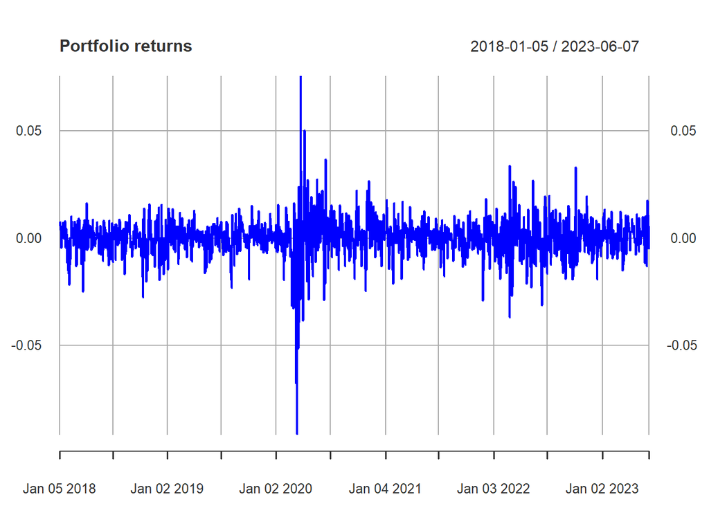

```r
## Plot of portfolio returns

plot(portfolio$PORTFOLIO_r,
     col = "blue",
     main = "Portfolio returns")
```

Checking skewness and kurtosis

```r
basicStats(portfolio$PORTFOLIO_r)
```

```
##             PORTFOLIO_r
## nobs        1411.000000
## NAs            0.000000
## Minimum       -0.091516
## Maximum        0.075429
## 1. Quartile   -0.004261
## 3. Quartile    0.004821
## Mean           0.000112
## Median         0.000513
## Sum            0.158676
## SE Mean        0.000249
## LCL Mean      -0.000377
## UCL Mean       0.000602
## Variance       0.000088
## Stdev          0.009370
## Skewness      -0.825809
## Kurtosis      13.232398
```

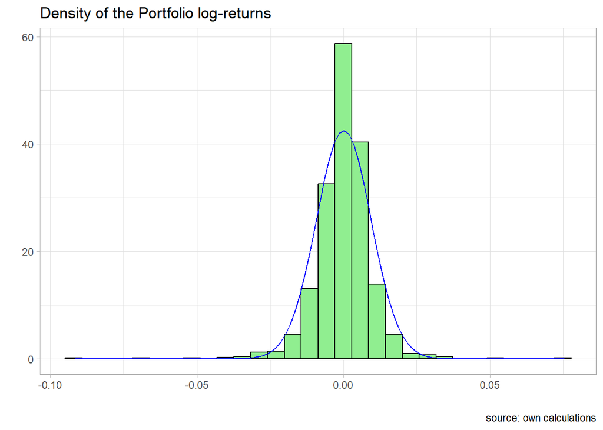

```r
# Plotting Histogram of Log-returns
tibble(r = as.numeric(portfolio$PORTFOLIO_r)) %>%
  ggplot(aes(r)) +
  geom_histogram(aes(y =..density..),
                 colour = "black",
                 fill = "light green") +
  stat_function(fun = dnorm,colour="blue",
                args = list(mean = mean(portfolio$PORTFOLIO_r),
                            sd = sd(portfolio$PORTFOLIO_r))) +
  theme_light() +
  labs(
    title = paste("Density of the Portfolio log-returns"),
    y = "", x = "",
    caption = "source: own calculations"
  )
```

Jarque-Bera statistic:

```r
jarque.bera.test(portfolio$PORTFOLIO_r)
```

```
##
##  Jarque Bera Test
##
## data:  portfolio$PORTFOLIO_r
## X-squared = 10491, df = 2, p-value < 2.2e-16
```

**Conclusion for this part:**

1. Skewness is negative: -0.825809

2. Kurtosis is 13.232398, it means strong excess kurtosis

3. The plot is leptokurtosis, “heavy tails” and higher peak in mean

4. According to the JB test, we reject the null hypothesis about normality. The null hypothesis is a joint hypothesis of the skewness being zero and the excess kurtosis being zero.

# ARCH Test

Let’s plot the ACF function of log-returns:

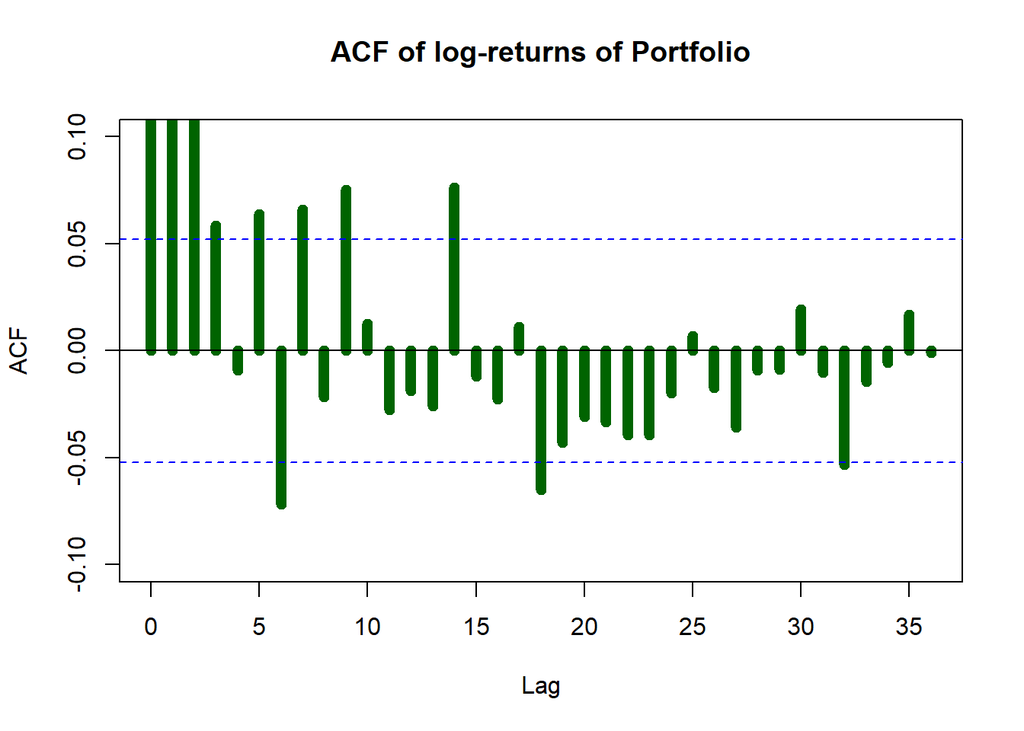

```r
acf(portfolio$PORTFOLIO_r,
    lag.max = 36,
    na.action = na.pass,
    ylim = c(-0.1,0.1), # we rescale the vertical axis
    col = "darkgreen",
    lwd = 7,
    main = "ACF of log-returns of Portfolio")
```

As seen, values of the ACF function indicate some autoregressive/MA relations among returns which can be used to build an ARIMA model.

Now, let’s also see the ACF values for for the **squared** log-returns:

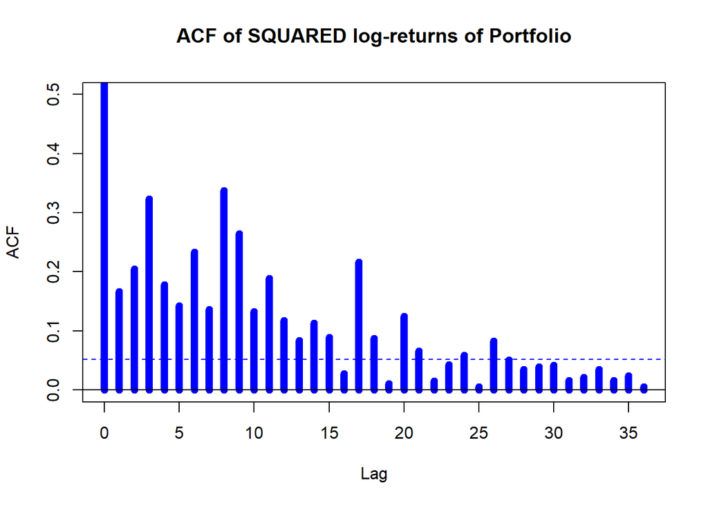

```r
acf(portfolio$PORTFOLIO_r ^ 2,
    lag.max = 36,
    na.action = na.pass,
    ylim = c(0,0.5), # we rescale the vertical axis
    col = "blue",
    lwd = 7,
    main = "ACF of SQUARED log-returns of Portfolio")
```

Let’s verify existence of ARCH effects among log-returns.

The ARCH test is based on the autocorrelation of **squared** returns.

```r
ArchTest(portfolio$PORTFOLIO_r,  # here we use a vector of returns as input
         lags = 5) # and maximum order of ARCH effect
```

```
##
##  ARCH LM-test; Null hypothesis: no ARCH effects
##
## data:  portfolio$PORTFOLIO_r
## Chi-squared = 199.13, df = 5, p-value < 2.2e-16
```

The null hypothesis about lack of ARCH effects strongly rejected!

*Note:* I check this test for different lags, for example, 5,10,15. All the lags indicate same result.

```r
durbinWatsonTest(lm(portfolio$PORTFOLIO_r^2 ~ 1),
                 max.lag = 5)
```

```
##  lag Autocorrelation D-W Statistic p-value
##    1       0.9999735             0       0
##    2       0.9999241             0       0
##    3       0.9998473             0       0
##    4       0.9995301             0       0
##    5       0.9994786             0       0
##  Alternative hypothesis: rho[lag] != 0
```

The null hypothesis for durbinWatsonTest about no autocorrelation in squared log returns is rejected.

# Modelling

Now, let’s try to find the most attractive GARCH(q, p) model.

## ARCH vs. GARCH models

### ARCH(1)

```r
k.arch1 <- garchFit(formula = ~ garch(1, 0), # GARCH(q, p)
                    # formula describing the mean and variance equation
                    # of the ARMA-GARCH - we assume that returns
                    # follow an ARCH(1) process
                    data = portfolio$PORTFOLIO_r,
                    # conditional distribution of errors
                    cond.dist = "norm",
                    # if we don't want to see the history of iterations
                    trace = FALSE)

# Summary of results and some diagnostic tests:

summary(k.arch1)
```

```
##
## Title:
##  GARCH Modelling
##
## Call:
##  garchFit(formula = ~garch(1, 0), data = portfolio$PORTFOLIO_r,
##     cond.dist = "norm", trace = FALSE)
##
## Mean and Variance Equation:
##  data ~ garch(1, 0)
## <environment: 0x000001761ed41840>
##  [data = portfolio$PORTFOLIO_r]
##
## Conditional Distribution:
##  norm
##
## Coefficient(s):
##          mu        omega       alpha1
## 0.000395971  0.000055517  0.360765610
##
## Std. Errors:
##  based on Hessian
##
## Error Analysis:
##           Estimate  Std. Error  t value           Pr(>|t|)
## mu     0.000395971 0.000225007    1.760             0.0784 .
## omega  0.000055517 0.000002734   20.303            < 2e-16 ***
## alpha1 0.360765610 0.047393905    7.612 0.0000000000000269 ***
## ---
## Signif. codes:  0 '***' 0.001 '**' 0.01 '*' 0.05 '.' 0.1 ' ' 1
##
## Log Likelihood:
##  4707.201    normalized:  3.336074
##
## Description:
##  Sat Jun 10 02:39:00 2023 by user: Afat
##
##
## Standardised Residuals Tests:
##                                 Statistic p-Value
##  Jarque-Bera Test   R    Chi^2  896.8216  0
##  Shapiro-Wilk Test  R    W      0.9574644 0
##  Ljung-Box Test     R    Q(10)  50.009    0.0000002658931
##  Ljung-Box Test     R    Q(15)  55.78099  0.000001319393
##  Ljung-Box Test     R    Q(20)  61.95712  0.00000353066
##  Ljung-Box Test     R^2  Q(10)  342.6751  0
##  Ljung-Box Test     R^2  Q(15)  544.9841  0
##  Ljung-Box Test     R^2  Q(20)  658.1399  0
##  LM Arch Test       R    TR^2   213.6483  0
##
## Information Criterion Statistics:
##       AIC       BIC       SIC      HQIC
## -6.667896 -6.656729 -6.667905 -6.663723
```

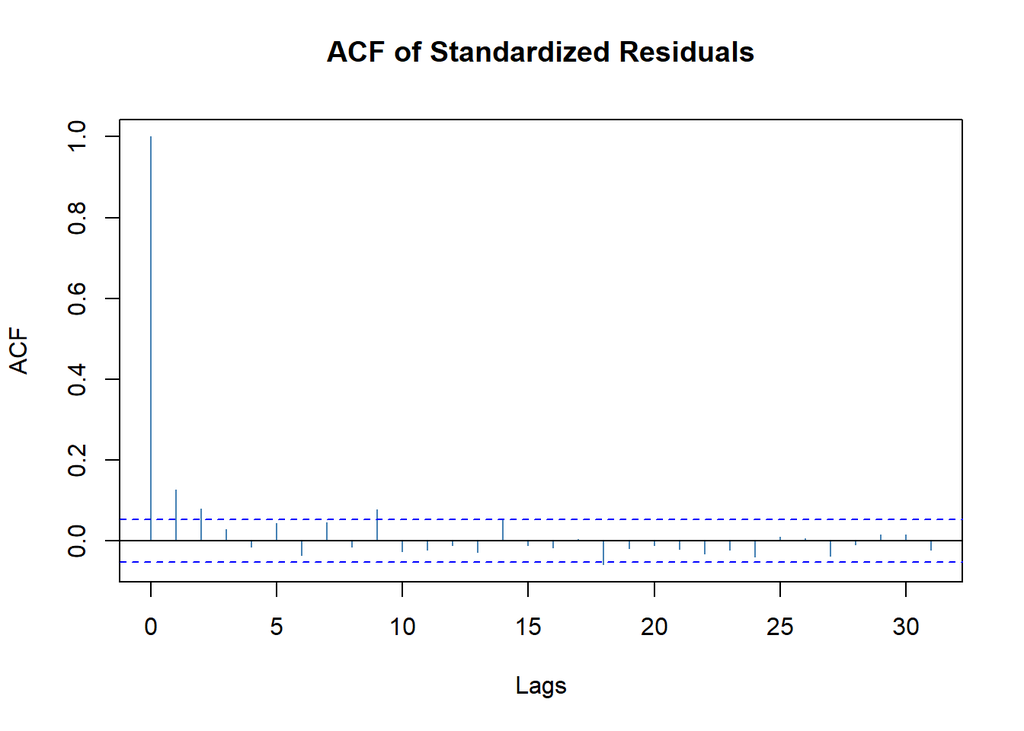

```r
plot(k.arch1, which = 10)
```

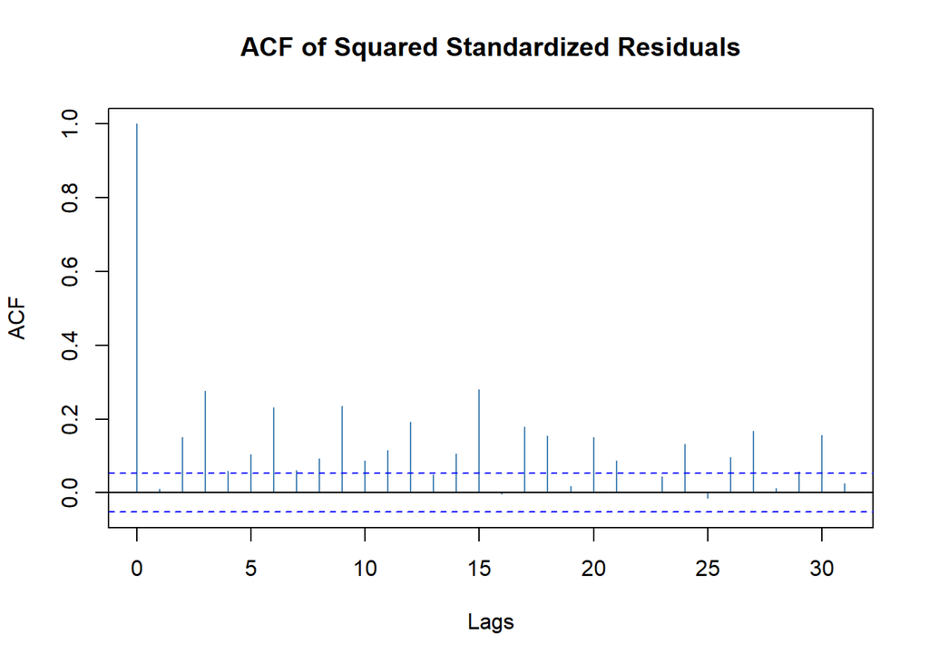

```r
plot(k.arch1, which = 11)
```

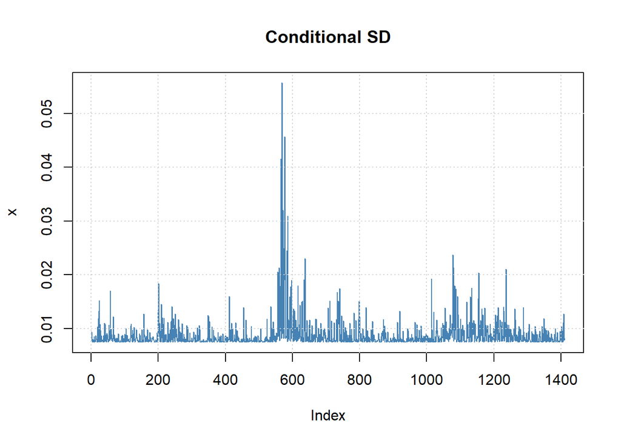

```r
plot(k.arch1, which = 2)
```

The parameters are denoted by the following symbols:

- mu - constant term in the mean equation
- omega - constant term in the variance equation
- alpha1 - arch1 parameter in the variance equation

If the intercept in the mean equation of the model above is not significant at 5% level, we can drop it.

Let’s drop it.

### ARCH(1) - without mu

```r
k.arch1a <- garchFit(~garch(1, 0),
                     data = portfolio$PORTFOLIO_r,
                     # remove intercept term in the mean equation
                     include.mean = FALSE,
                     # conditional distribution of errors
                     cond.dist = "norm",
                     trace = FALSE)
summary(k.arch1a)
```

```
##
## Title:
##  GARCH Modelling
##
## Call:
##  garchFit(formula = ~garch(1, 0), data = portfolio$PORTFOLIO_r,
##     cond.dist = "norm", include.mean = FALSE, trace = FALSE)
##
## Mean and Variance Equation:
##  data ~ garch(1, 0)
## <environment: 0x000001761a2bfae8>
##  [data = portfolio$PORTFOLIO_r]
##
## Conditional Distribution:
##  norm
##
## Coefficient(s):
##       omega       alpha1
## 0.000055785  0.356339235
##
## Std. Errors:
##  based on Hessian
##
## Error Analysis:
##           Estimate  Std. Error  t value           Pr(>|t|)
## omega  0.000055785 0.000002738   20.371            < 2e-16 ***
## alpha1 0.356339235 0.046747825    7.623 0.0000000000000249 ***
## ---
## Signif. codes:  0 '***' 0.001 '**' 0.01 '*' 0.05 '.' 0.1 ' ' 1
##
## Log Likelihood:
##  4705.656    normalized:  3.334979
##
## Description:
##  Sat Jun 10 02:39:01 2023 by user: Afat
##
##
## Standardised Residuals Tests:
##                                 Statistic p-Value
##  Jarque-Bera Test   R    Chi^2  901.3351  0
##  Shapiro-Wilk Test  R    W      0.9568953 0
##  Ljung-Box Test     R    Q(10)  51.00999  0.0000001739028
##  Ljung-Box Test     R    Q(15)  56.78603  0.0000008921659
##  Ljung-Box Test     R    Q(20)  62.97274  0.000002445172
##  Ljung-Box Test     R^2  Q(10)  347.4405  0
##  Ljung-Box Test     R^2  Q(15)  543.6051  0
##  Ljung-Box Test     R^2  Q(20)  662.1416  0
##  LM Arch Test       R    TR^2   214.7196  0
##
## Information Criterion Statistics:
##       AIC       BIC       SIC      HQIC
## -6.667124 -6.659679 -6.667128 -6.664342
```

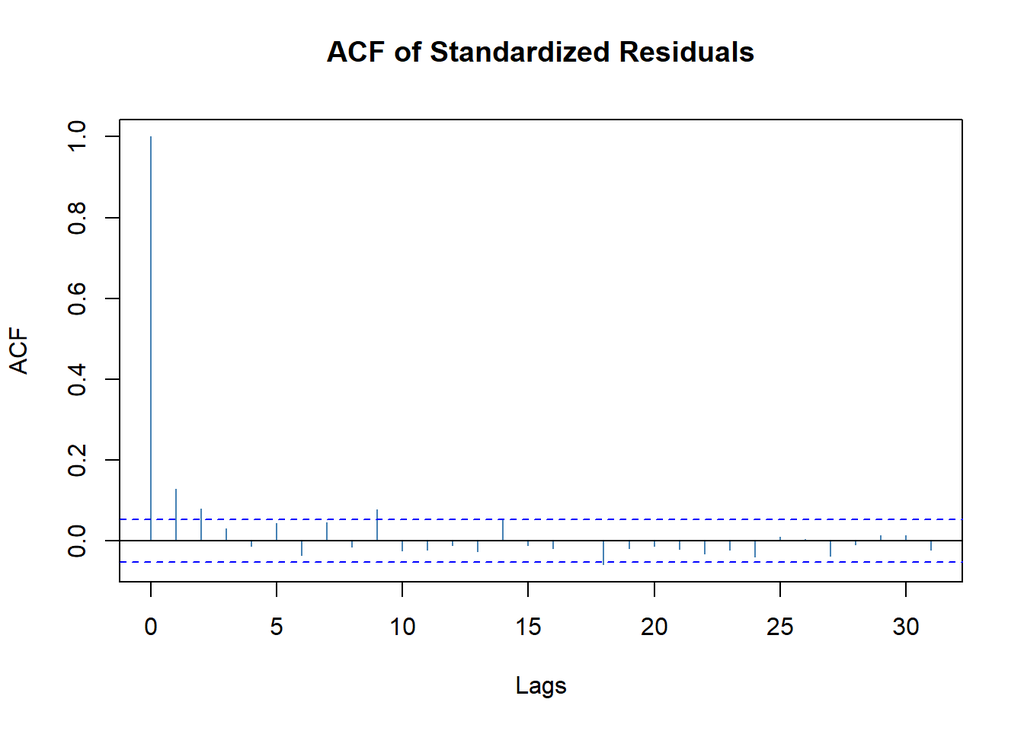

```r
plot(k.arch1a, which = 10)
```

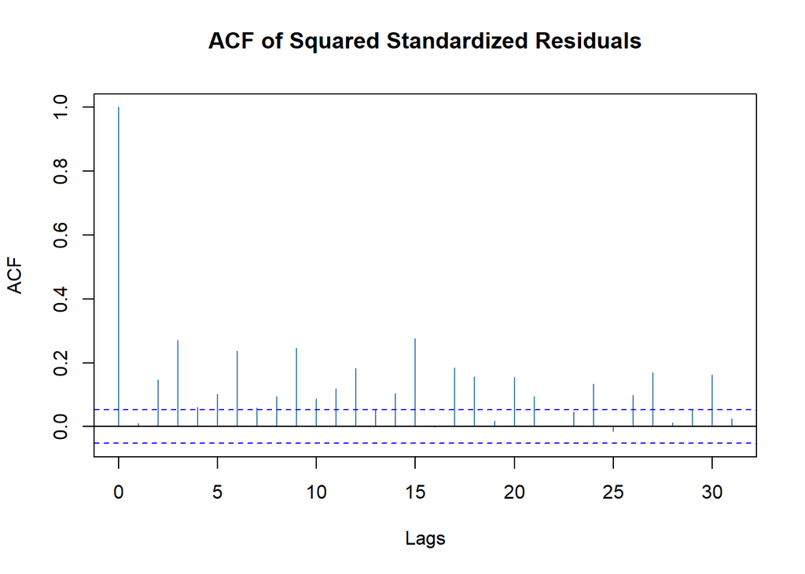

```r
plot(k.arch1a, which = 11)
```

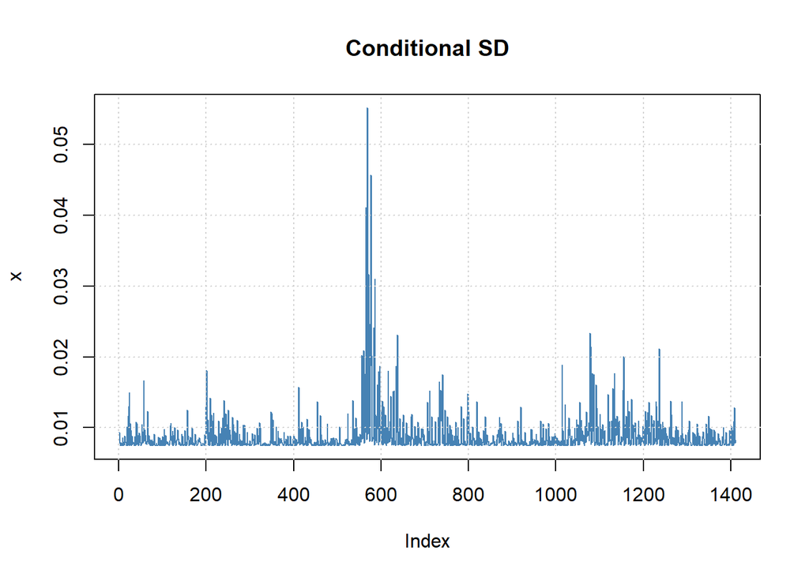

```r
plot(k.arch1a, which = 2)
```

- Significant lags are observed for square residuals for lags 2-12, 14-15.
- And the Ljung-Box test for R^2 shows there is autocorrelation at 5% level.

Let’s try ARCH(5).

### ARCH(5)

```r
k.arch5 <- garchFit(~garch(5, 0),
                    data = portfolio$PORTFOLIO_r,
                    include.mean = TRUE,
                    cond.dist = "norm",
                    trace = FALSE)
summary(k.arch5)
```

```
##
## Title:
##  GARCH Modelling
##
## Call:
##  garchFit(formula = ~garch(5, 0), data = portfolio$PORTFOLIO_r,
##     cond.dist = "norm", include.mean = TRUE, trace = FALSE)
##
## Mean and Variance Equation:
##  data ~ garch(5, 0)
## <environment: 0x0000017610b3a5a8>
##  [data = portfolio$PORTFOLIO_r]
##
## Conditional Distribution:
##  norm
##
## Coefficient(s):
##         mu       omega      alpha1      alpha2      alpha3      alpha4
## 0.00058468  0.00003037  0.19984238  0.12327532  0.13759187  0.05961714
##     alpha5
## 0.10145912
##
## Std. Errors:
##  based on Hessian
##
## Error Analysis:
##           Estimate  Std. Error  t value     Pr(>|t|)
## mu     0.000584684 0.000201144    2.907     0.003651 **
## omega  0.000030370 0.000002542   11.949      < 2e-16 ***
## alpha1 0.199842381 0.037488746    5.331 0.0000000978 ***
## alpha2 0.123275323 0.035821390    3.441     0.000579 ***
## alpha3 0.137591875 0.030913579    4.451 0.0000085529 ***
## alpha4 0.059617140 0.027595777    2.160     0.030744 *
## alpha5 0.101459119 0.027414360    3.701     0.000215 ***
## ---
## Signif. codes:  0 '***' 0.001 '**' 0.01 '*' 0.05 '.' 0.1 ' ' 1
##
## Log Likelihood:
##  4801.855    normalized:  3.403158
##
## Description:
##  Sat Jun 10 02:39:03 2023 by user: Afat
##
##
## Standardised Residuals Tests:
##                                 Statistic p-Value
##  Jarque-Bera Test   R    Chi^2  199.4434  0
##  Shapiro-Wilk Test  R    W      0.9803067 0.0000000000005687308
##  Ljung-Box Test     R    Q(10)  49.74823  0.0000002969223
##  Ljung-Box Test     R    Q(15)  54.84556  0.000001895762
##  Ljung-Box Test     R    Q(20)  56.53469  0.00002414133
##  Ljung-Box Test     R^2  Q(10)  26.68328  0.002922152
##  Ljung-Box Test     R^2  Q(15)  33.08964  0.004561671
##  Ljung-Box Test     R^2  Q(20)  47.99676  0.0004258418
##  LM Arch Test       R    TR^2   31.65736  0.001562556
##
## Information Criterion Statistics:
##       AIC       BIC       SIC      HQIC
## -6.796393 -6.770337 -6.796442 -6.786657
```

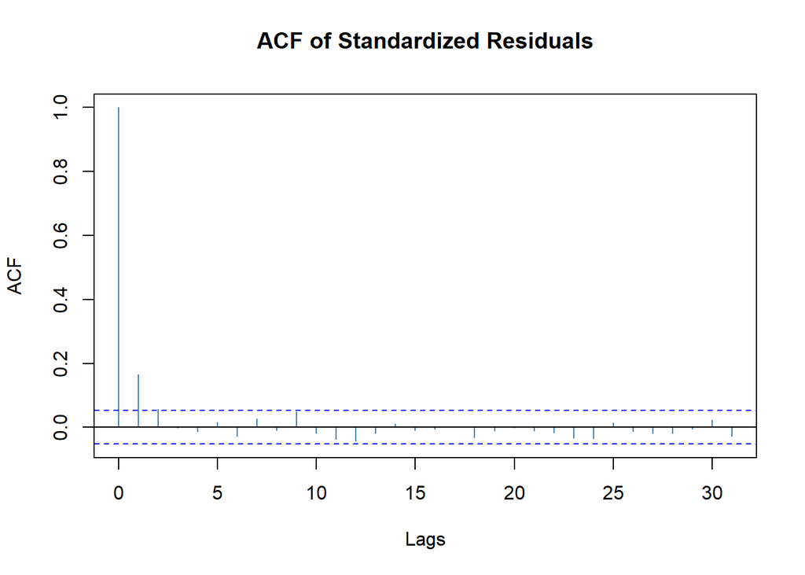

```r
plot(k.arch5, which = 10)
```

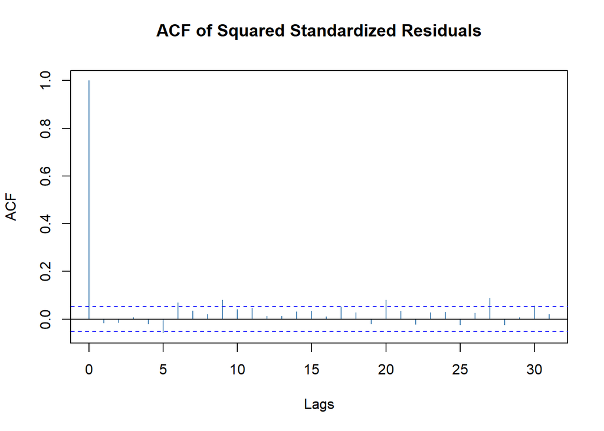

```r
plot(k.arch5, which = 11)
```

- All parameters are significant.
- The Ljung-box tests for R and R^2 show there is still autocorrelation.
- The lags 5,6,9,in ACF for squared residuals seem to be still significant.

### ARCH(10)

```r
k.arch10 <- garchFit(~garch(10, 0),
                    data = portfolio$PORTFOLIO_r,
                    include.mean = TRUE,
                    cond.dist = "norm",
                    trace = FALSE)
summary(k.arch10)
```

```
##
## Title:
##  GARCH Modelling
##
## Call:
##  garchFit(formula = ~garch(10, 0), data = portfolio$PORTFOLIO_r,
##     cond.dist = "norm", include.mean = TRUE, trace = FALSE)
##
## Mean and Variance Equation:
##  data ~ garch(10, 0)
## <environment: 0x000001761759e830>
##  [data = portfolio$PORTFOLIO_r]
##
## Conditional Distribution:
##  norm
##
## Coefficient(s):
##          mu        omega       alpha1       alpha2       alpha3       alpha4
## 0.000224503  0.000025715  0.157809693  0.113678887  0.082557501  0.000041953
##      alpha5       alpha6       alpha7       alpha8       alpha9      alpha10
## 0.007756408  0.105448679  0.052882032  0.057070507  0.066085512  0.001063304
##
## Std. Errors:
##  based on Hessian
##
## Error Analysis:
##            Estimate  Std. Error  t value   Pr(>|t|)
## mu      0.000224503 0.000206651    1.086   0.277307
## omega   0.000025715 0.000002832    9.080    < 2e-16 ***
## alpha1  0.157809693 0.035018142    4.507 0.00000659 ***
## alpha2  0.113678887 0.033422464    3.401   0.000671 ***
## alpha3  0.082557501 0.027085778    3.048   0.002304 **
## alpha4  0.000041953 0.027528897    0.002   0.998784
## alpha5  0.007756408 0.022974658    0.338   0.735659
## alpha6  0.105448679 0.030508802    3.456   0.000548 ***
## alpha7  0.052882032 0.027497815    1.923   0.054463 .
## alpha8  0.057070507 0.028661226    1.991   0.046458 *
## alpha9  0.066085512 0.028231298    2.341   0.019239 *
## alpha10 0.001063304 0.019702727    0.054   0.956961
## ---
```

[output cut: 9 more lines]

```
## Standardised Residuals Tests:
##                                 Statistic p-Value
##  Jarque-Bera Test   R    Chi^2  175.0908  0
##  Shapiro-Wilk Test  R    W      0.9813399 0.000000000001502765
##  Ljung-Box Test     R    Q(10)  53.93162  0.00000004996649
##  Ljung-Box Test     R    Q(15)  57.66032  0.0000006338253
##  Ljung-Box Test     R    Q(20)  59.62968  0.000008125135
##  Ljung-Box Test     R^2  Q(10)  4.417564  0.9265505
##  Ljung-Box Test     R^2  Q(15)  6.744575  0.9643538
##  Ljung-Box Test     R^2  Q(20)  14.66373  0.795315
##  LM Arch Test       R    TR^2   4.328423  0.9767547
##
## Information Criterion Statistics:
##       AIC       BIC       SIC      HQIC
## -6.828751 -6.784085 -6.828894 -6.812061
```

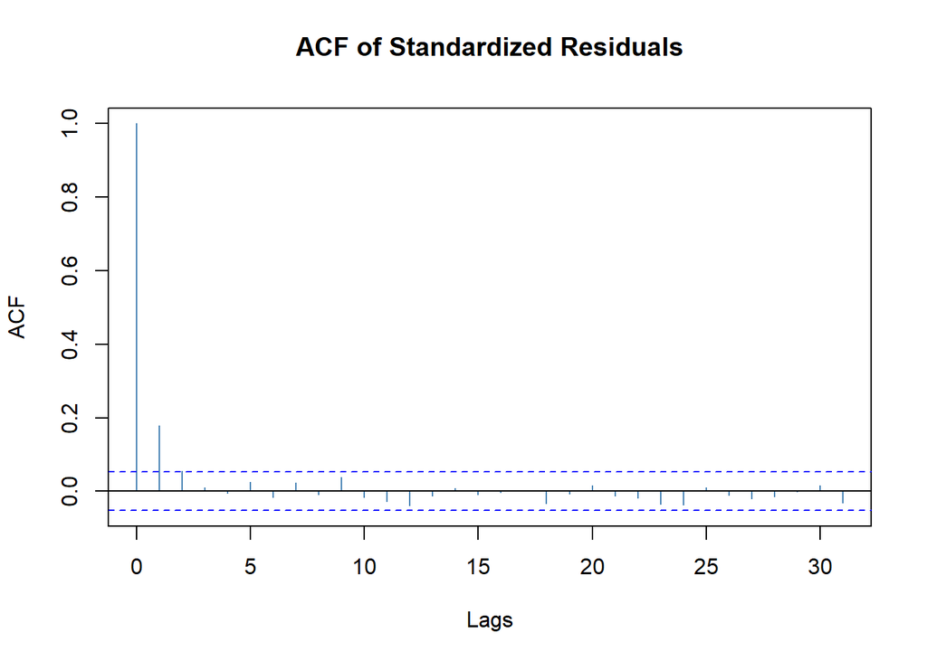

```r
plot(k.arch10, which = 10)
```

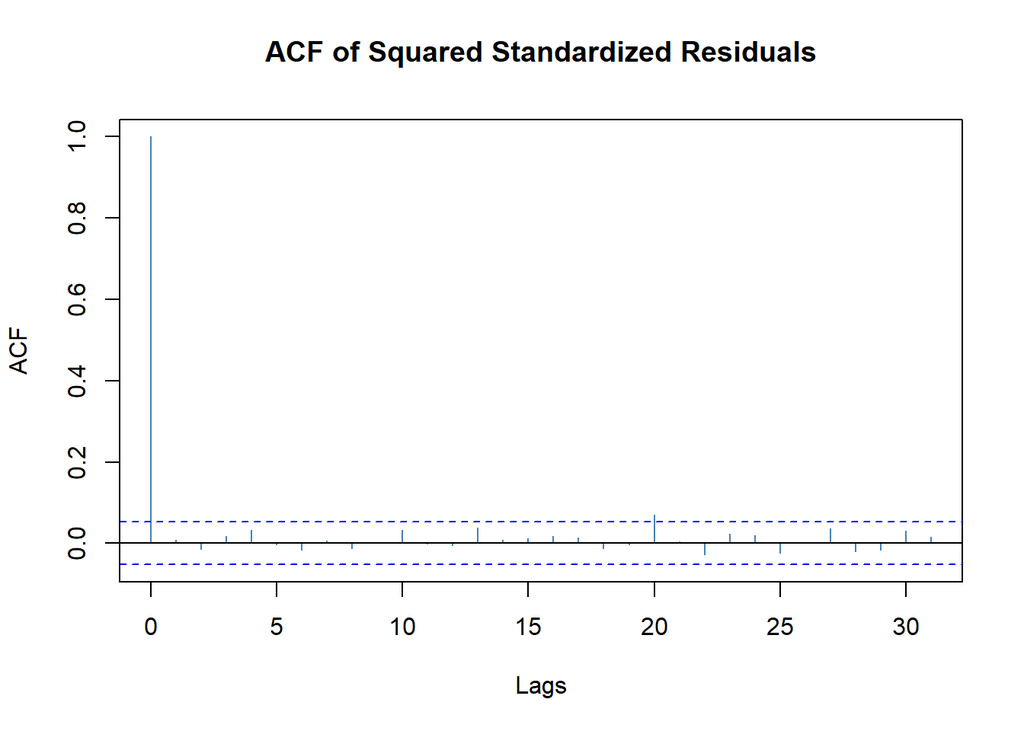

```r
plot(k.arch10, which = 11)
```

- Again most of parameters are significant at 5% level - excluding 4,5,7,10.
- The Ljung-box test for R^2 shows there is no more autocorrelation between the current and past standardized squared residuals.
- It looks like no further extension of the **conditional variance** equation is needed.

### GARCH (1,1)

```r
k.garch11 <- garchFit(~garch(1, 1),
                      data = portfolio$PORTFOLIO_r,
                      include.mean = TRUE,
                      cond.dist = "norm",
                      trace = FALSE)
summary(k.garch11)
```

```
##
## Title:
##  GARCH Modelling
##
## Call:
##  garchFit(formula = ~garch(1, 1), data = portfolio$PORTFOLIO_r,
##     cond.dist = "norm", include.mean = TRUE, trace = FALSE)
##
## Mean and Variance Equation:
##  data ~ garch(1, 1)
## <environment: 0x0000017621d54bd8>
##  [data = portfolio$PORTFOLIO_r]
##
## Conditional Distribution:
##  norm
##
## Coefficient(s):
##           mu         omega        alpha1         beta1
## 0.0005114340  0.0000036771  0.1232450107  0.8273803559
##
## Std. Errors:
##  based on Hessian
##
## Error Analysis:
##            Estimate   Std. Error  t value      Pr(>|t|)
## mu     0.0005114340 0.0001986127    2.575      0.010023 *
## omega  0.0000036771 0.0000009569    3.843      0.000122 ***
## alpha1 0.1232450107 0.0213528512    5.772 0.00000000784 ***
## beta1  0.8273803559 0.0291275455   28.405       < 2e-16 ***
## ---
## Signif. codes:  0 '***' 0.001 '**' 0.01 '*' 0.05 '.' 0.1 ' ' 1
##
## Log Likelihood:
##  4827.036    normalized:  3.421004
##
## Description:
##  Sat Jun 10 02:39:29 2023 by user: Afat
##
##
## Standardised Residuals Tests:
##                                 Statistic p-Value
##  Jarque-Bera Test   R    Chi^2  199.2463  0
##  Shapiro-Wilk Test  R    W      0.9801788 0.0000000000005054593
##  Ljung-Box Test     R    Q(10)  57.13202  0.00000001258952
##  Ljung-Box Test     R    Q(15)  61.3389   0.0000001482334
##  Ljung-Box Test     R    Q(20)  62.85605  0.00000255087
##  Ljung-Box Test     R^2  Q(10)  5.963117  0.8183524
##  Ljung-Box Test     R^2  Q(15)  6.562335  0.9686776
##  Ljung-Box Test     R^2  Q(20)  10.83105  0.9504867
##  LM Arch Test       R    TR^2   5.814517  0.9251418
##
## Information Criterion Statistics:
##       AIC       BIC       SIC      HQIC
## -6.836338 -6.821449 -6.836354 -6.830774
```

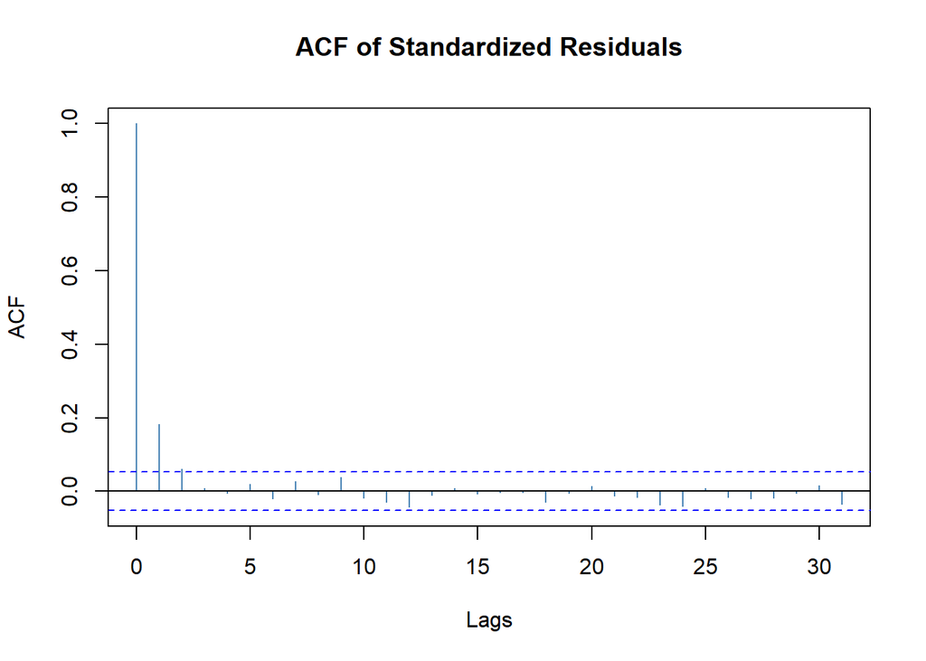

```r
plot(k.garch11, which = 10)
```

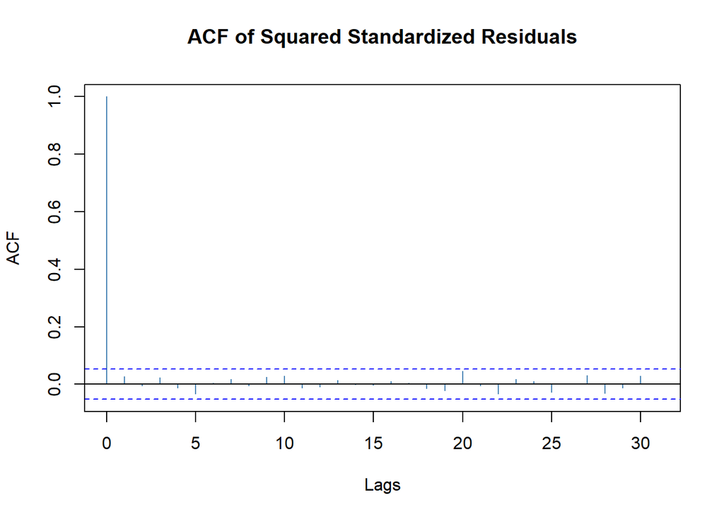

```r
plot(k.garch11, which = 11)
```

- All parameters are significant.
- The Ljung-Box test for R^2 does not show autocorrelation at 5% level between the current and past standardized squared residuals (variance).
- The **conditional variance** equation seems to be complete, however the ACF plot of residuals indicates that we may still improve the model by adding AR components in the **mean** equation.

mu is less significant than other parameters, let’s try without mu: *(just for fun)*

### GARCH(1,1) - without mu

```r
k.garch11a <- garchFit(~garch(1, 1),
                      data = portfolio$PORTFOLIO_r,
                      include.mean = FALSE,
                      cond.dist = "norm",
                      trace = FALSE)
summary(k.garch11a)
```

```
##
## Title:
##  GARCH Modelling
##
## Call:
##  garchFit(formula = ~garch(1, 1), data = portfolio$PORTFOLIO_r,
##     cond.dist = "norm", include.mean = FALSE, trace = FALSE)
##
## Mean and Variance Equation:
##  data ~ garch(1, 1)
## <environment: 0x0000017633eb3ec8>
##  [data = portfolio$PORTFOLIO_r]
##
## Conditional Distribution:
##  norm
##
## Coefficient(s):
##        omega        alpha1         beta1
## 0.0000033781  0.1134504944  0.8407257391
##
## Std. Errors:
##  based on Hessian
##
## Error Analysis:
##            Estimate   Std. Error  t value      Pr(>|t|)
## omega  0.0000033781 0.0000009129    3.700      0.000215 ***
## alpha1 0.1134504944 0.0197134318    5.755 0.00000000866 ***
## beta1  0.8407257391 0.0275145087   30.556       < 2e-16 ***
## ---
## Signif. codes:  0 '***' 0.001 '**' 0.01 '*' 0.05 '.' 0.1 ' ' 1
##
## Log Likelihood:
##  4823.741    normalized:  3.418669
##
## Description:
##  Sat Jun 10 02:39:29 2023 by user: Afat
##
##
## Standardised Residuals Tests:
##                                 Statistic p-Value
##  Jarque-Bera Test   R    Chi^2  224.6002  0
##  Shapiro-Wilk Test  R    W      0.9785581 0.0000000000001182709
##  Ljung-Box Test     R    Q(10)  58.03366  0.000000008519483
##  Ljung-Box Test     R    Q(15)  61.71268  0.0000001277282
##  Ljung-Box Test     R    Q(20)  63.21413  0.000002240019
##  Ljung-Box Test     R^2  Q(10)  7.457428  0.6816695
##  Ljung-Box Test     R^2  Q(15)  8.042589  0.9220639
##  Ljung-Box Test     R^2  Q(20)  11.73929  0.9247572
##  LM Arch Test       R    TR^2   7.247965  0.8408013
##
## Information Criterion Statistics:
##       AIC       BIC       SIC      HQIC
## -6.833085 -6.821918 -6.833094 -6.828912
```

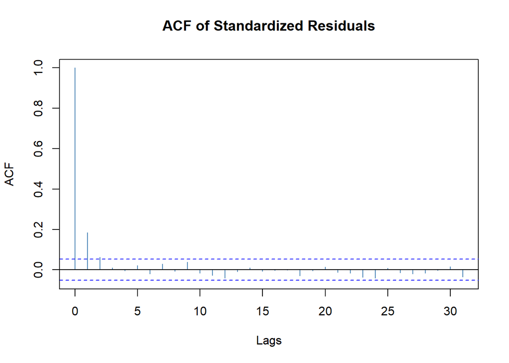

```r
plot(k.garch11a, which = 10)
```

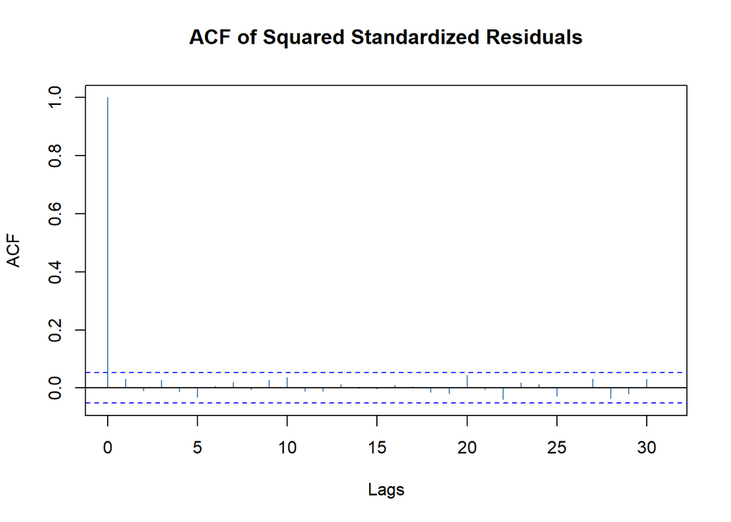

```r
plot(k.garch11a, which = 11)
```

- All parameters are significant.
- The Ljung-Box test for R^2 does not show autocorrelation at 5% level between the current and past standardized squared residuals (variance).
- ACF for R^2 looks much better.

### AR(5)-GARCH(1,1)

```r
k.ar5garch11 <- garchFit(~arma(5, 0) + garch(1, 1),
                         data = portfolio$PORTFOLIO_r,
                         include.mean = TRUE,
                         cond.dist = "norm",
                         trace = FALSE)
summary(k.ar5garch11)
```

```
##
## Title:
##  GARCH Modelling
##
## Call:
##  garchFit(formula = ~arma(5, 0) + garch(1, 1), data = portfolio$PORTFOLIO_r,
##     cond.dist = "norm", include.mean = TRUE, trace = FALSE)
##
## Mean and Variance Equation:
##  data ~ arma(5, 0) + garch(1, 1)
## <environment: 0x000001761f006b80>
##  [data = portfolio$PORTFOLIO_r]
##
## Conditional Distribution:
##  norm
##
## Coefficient(s):
##           mu           ar1           ar2           ar3           ar4
##  0.000393766   0.189310699   0.021577118  -0.022853581  -0.025334596
##          ar5         omega        alpha1         beta1
##  0.011807692   0.000003365   0.120518800   0.832869343
##
## Std. Errors:
##  based on Hessian
##
## Error Analysis:
##             Estimate    Std. Error  t value        Pr(>|t|)
## mu      0.0003937656  0.0001932927    2.037        0.041635 *
## ar1     0.1893106989  0.0292047913    6.482 0.0000000000904 ***
## ar2     0.0215771180  0.0291587829    0.740        0.459308
## ar3    -0.0228535808  0.0286198700   -0.799        0.424568
## ar4    -0.0253345958  0.0285008008   -0.889        0.374052
## ar5     0.0118076921  0.0277178148    0.426        0.670110
## omega   0.0000033650  0.0000008732    3.854        0.000116 ***
## alpha1  0.1205187999  0.0201528363    5.980 0.0000000022281 ***
## beta1   0.8328693432  0.0272063354   30.613         < 2e-16 ***
## ---
## Signif. codes:  0 '***' 0.001 '**' 0.01 '*' 0.05 '.' 0.1 ' ' 1
##
## Log Likelihood:
##  4850.894    normalized:  3.437912
##
## Description:
##  Sat Jun 10 02:39:30 2023 by user: Afat
##
##
## Standardised Residuals Tests:
##                                 Statistic p-Value
##  Jarque-Bera Test   R    Chi^2  181.5494  0
##  Shapiro-Wilk Test  R    W      0.9820385 0.000000000002957727
##  Ljung-Box Test     R    Q(10)  9.240415  0.5094495
##  Ljung-Box Test     R    Q(15)  12.29598  0.6565018
##  Ljung-Box Test     R    Q(20)  14.27696  0.8161805
##  Ljung-Box Test     R^2  Q(10)  5.530908  0.8530161
##  Ljung-Box Test     R^2  Q(15)  6.378856  0.9726573
##  Ljung-Box Test     R^2  Q(20)  11.45828  0.9334616
##  LM Arch Test       R    TR^2   5.737103  0.9287502
##
## Information Criterion Statistics:
##       AIC       BIC       SIC      HQIC
## -6.863067 -6.829567 -6.863148 -6.850549
```

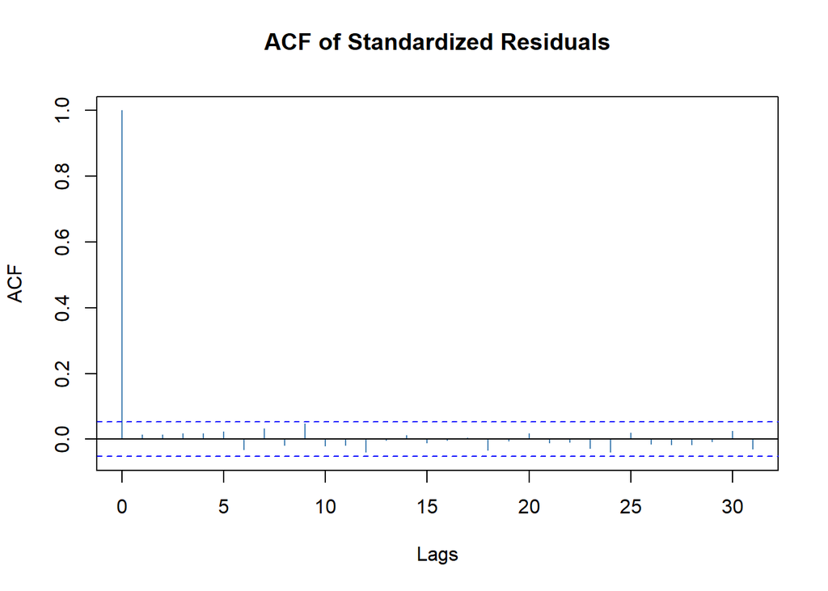

```r
plot(k.ar5garch11, which = 10)
```

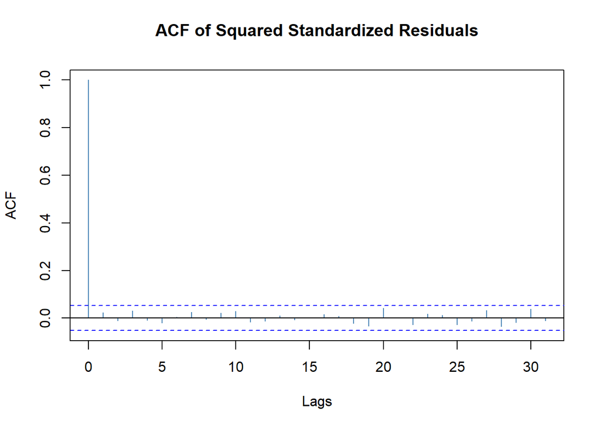

```r
plot(k.ar5garch11, which = 11)
```

- Except AR2,AR3,AR4,AR5, other parameters are significant.
- The Ljung-box test for R^2 shows there is no more autocorrelation between the current and past standardized squared residuals. Similarly, there is no autocorrelation among returns after adding AR part now.
- Both ACF figures show no significant lags.

Since moast of AR parameters are insignificant, let’s try simplier version:

### AR(1)-GARCH(1,1)

```r
k.ar1garch11 <- garchFit(~arma(1, 0) + garch(1, 1),
                         data = portfolio$PORTFOLIO_r,
                         include.mean = TRUE,
                         cond.dist = "norm",
                         trace = FALSE)
summary(k.ar1garch11)
```

```
##
## Title:
##  GARCH Modelling
##
## Call:
##  garchFit(formula = ~arma(1, 0) + garch(1, 1), data = portfolio$PORTFOLIO_r,
##     cond.dist = "norm", include.mean = TRUE, trace = FALSE)
##
## Mean and Variance Equation:
##  data ~ arma(1, 0) + garch(1, 1)
## <environment: 0x00000176228dc368>
##  [data = portfolio$PORTFOLIO_r]
##
## Conditional Distribution:
##  norm
##
## Coefficient(s):
##           mu           ar1         omega        alpha1         beta1
## 0.0003778567  0.1923029582  0.0000033356  0.1187827902  0.8348469991
##
## Std. Errors:
##  based on Hessian
##
## Error Analysis:
##            Estimate   Std. Error  t value        Pr(>|t|)
## mu     0.0003778567 0.0001900913    1.988        0.046838 *
## ar1    0.1923029582 0.0287115717    6.698 0.0000000000212 ***
## omega  0.0000033356 0.0000008646    3.858        0.000114 ***
## alpha1 0.1187827902 0.0196749363    6.037 0.0000000015675 ***
## beta1  0.8348469991 0.0267119160   31.254         < 2e-16 ***
## ---
## Signif. codes:  0 '***' 0.001 '**' 0.01 '*' 0.05 '.' 0.1 ' ' 1
##
## Log Likelihood:
##  4849.482    normalized:  3.436911
##
## Description:
##  Sat Jun 10 02:39:31 2023 by user: Afat
##
##
## Standardised Residuals Tests:
##                                 Statistic p-Value
##  Jarque-Bera Test   R    Chi^2  179.4611  0
##  Shapiro-Wilk Test  R    W      0.9824781 0.000000000004569137
##  Ljung-Box Test     R    Q(10)  10.19472  0.4235794
##  Ljung-Box Test     R    Q(15)  13.24521  0.5833647
##  Ljung-Box Test     R    Q(20)  15.18299  0.7658431
##  Ljung-Box Test     R^2  Q(10)  5.358894  0.8659513
##  Ljung-Box Test     R^2  Q(15)  5.983937  0.9800163
##  Ljung-Box Test     R^2  Q(20)  10.86977  0.94953
##  LM Arch Test       R    TR^2   5.382601  0.9439649
##
## Information Criterion Statistics:
##       AIC       BIC       SIC      HQIC
## -6.866735 -6.848124 -6.866760 -6.859781
```

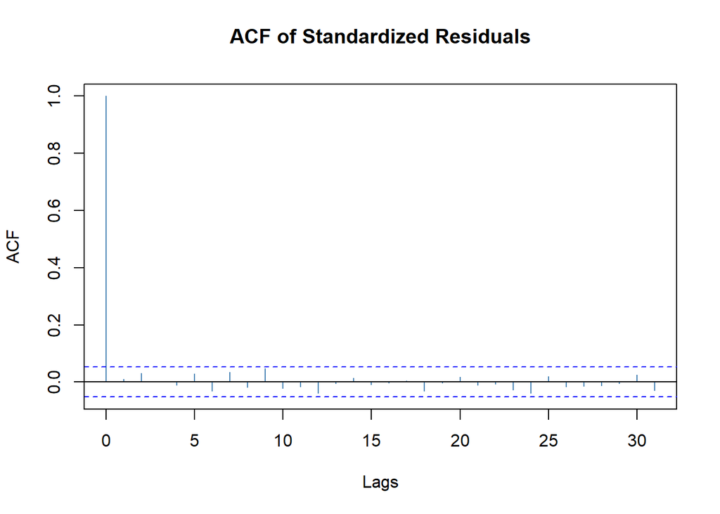

```r
plot(k.ar1garch11, which = 10)
```

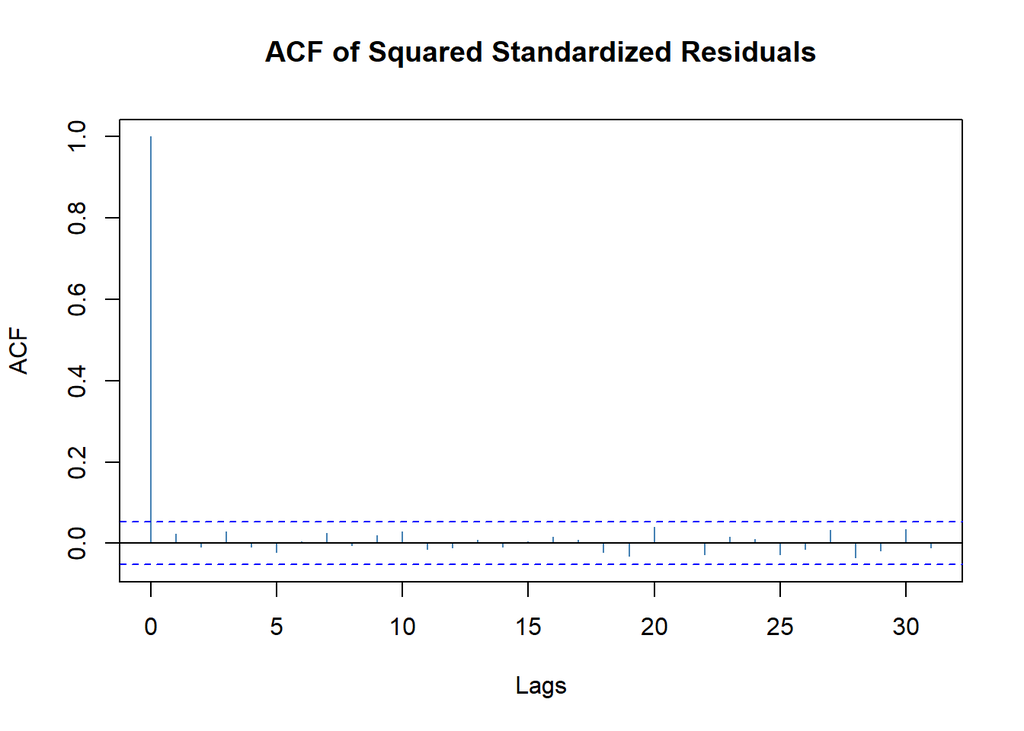

```r
plot(k.ar1garch11, which = 11)
```

- All parameters are significant.
- The Ljung-box test for R^2 shows there is no more autocorrelation between the current and past standardized squared residuals. Similarly, there is no autocorrelation among returns after adding AR part now.
- Both ACF figures show no significant lags.

### AR(1)-ARCH(10)

```r
tic()
k.ar1arch10 <- garchFit(~arma(1, 0) + garch(10, 0),
                        data = portfolio$PORTFOLIO_r,
                        include.mean = TRUE,
                        cond.dist = "norm",
                        trace = FALSE)
toc()
```

```
## 29.44 sec elapsed
```

```r
summary(k.ar1arch10)
```

```
##
## Title:
##  GARCH Modelling
##
## Call:
##  garchFit(formula = ~arma(1, 0) + garch(10, 0), data = portfolio$PORTFOLIO_r,
##     cond.dist = "norm", include.mean = TRUE, trace = FALSE)
##
## Mean and Variance Equation:
##  data ~ arma(1, 0) + garch(10, 0)
## <environment: 0x0000017633d6fb68>
##  [data = portfolio$PORTFOLIO_r]
##
## Conditional Distribution:
##  norm
##
## Coefficient(s):
##          mu          ar1        omega       alpha1       alpha2       alpha3
## 0.000186865  0.187177693  0.000024176  0.139092858  0.095385719  0.091719033
##      alpha4       alpha5       alpha6       alpha7       alpha8       alpha9
## 0.021057796  0.026340626  0.098763768  0.070268560  0.045033682  0.065791924
##     alpha10
## 0.001454902
##
## Std. Errors:
##  based on Hessian
##
## Error Analysis:
##            Estimate  Std. Error  t value       Pr(>|t|)
## mu      0.000186865 0.000196599    0.950        0.34186
## ar1     0.187177693 0.029494909    6.346 0.000000000221 ***
## omega   0.000024176 0.000002811    8.600        < 2e-16 ***
## alpha1  0.139092858 0.032948813    4.221 0.000024270017 ***
## alpha2  0.095385719 0.032499139    2.935        0.00334 **
## alpha3  0.091719033 0.028993020    3.163        0.00156 **
## alpha4  0.021057796 0.030146307    0.699        0.48485
## alpha5  0.026340626 0.025884668    1.018        0.30886
## alpha6  0.098763768 0.032477492    3.041        0.00236 **
## alpha7  0.070268560 0.032369248    2.171        0.02994 *
## alpha8  0.045033682 0.029226509    1.541        0.12335
```

[output cut: 12 more lines]

```
## Standardised Residuals Tests:
##                                 Statistic p-Value
##  Jarque-Bera Test   R    Chi^2  161.5933  0
##  Shapiro-Wilk Test  R    W      0.9833877 0.00000000001149736
##  Ljung-Box Test     R    Q(10)  9.692957  0.4678315
##  Ljung-Box Test     R    Q(15)  12.54405  0.6374694
##  Ljung-Box Test     R    Q(20)  15.12237  0.7693633
##  Ljung-Box Test     R^2  Q(10)  3.62497   0.9626838
##  Ljung-Box Test     R^2  Q(15)  4.99083   0.9922038
##  Ljung-Box Test     R^2  Q(20)  13.04892  0.8752753
##  LM Arch Test       R    TR^2   3.521838  0.9906043
##
## Information Criterion Statistics:
##       AIC       BIC       SIC      HQIC
## -6.855986 -6.807597 -6.856153 -6.837904
```

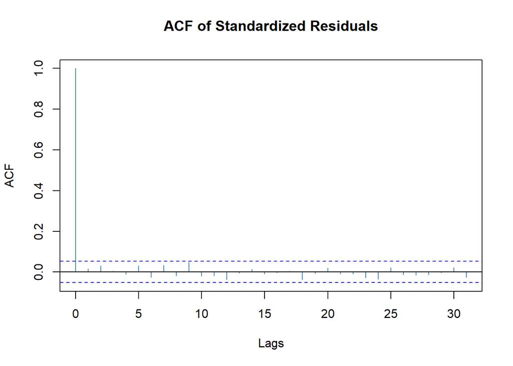

```r
plot(k.ar1arch10, which = 10)
```

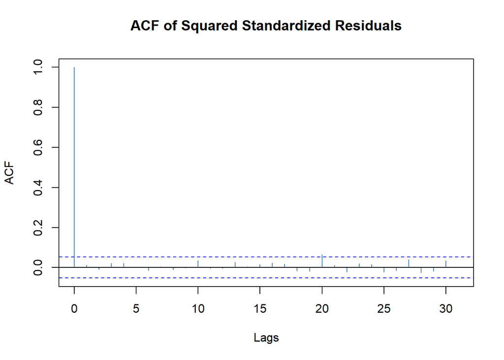

```r
plot(k.ar1arch10, which = 11)
```

### Result: ARCH vs GARCH

Let’s compare the models using above mentioned fucntion:

```r
compare_ICs_GARCH(c("k.arch1",
                    "k.arch1a",
                    "k.arch5",
                    "k.arch10",
                    "k.garch11",
                    "k.garch11a",
                    "k.ar5garch11",
                    "k.ar1garch11",
                    "k.ar1arch10"))
```

```
## $ICs
##         AIC       BIC       SIC      HQIC        model
## 1 -6.667896 -6.656729 -6.667905 -6.663723      k.arch1
## 2 -6.667124 -6.659679 -6.667128 -6.664342     k.arch1a
## 3 -6.796393 -6.770337 -6.796442 -6.786657      k.arch5
## 4 -6.828751 -6.784085 -6.828894 -6.812061     k.arch10
## 5 -6.836338 -6.821449 -6.836354 -6.830774    k.garch11
## 6 -6.833085 -6.821918 -6.833094 -6.828912   k.garch11a
## 7 -6.863067 -6.829567 -6.863148 -6.850549 k.ar5garch11
## 8 -6.866735 -6.848124 -6.866760 -6.859781 k.ar1garch11
## 9 -6.855986 -6.807597 -6.856153 -6.837904  k.ar1arch10
##
## $which.min
##  AIC  BIC  SIC HQIC
##    8    8    8    8
```

The comparison shows that 8th - **AR(1)-GARCH(1,1)** is the best model among others.

I will use this model for other GARCH extensions.

Let’s turn the page for new chapter! <sup>.</sup>

# GARCH extensions

## EGARCH model

Let’s define a model specification:

### AR(1)-EGARCH(1,1)

```r
spec <- ugarchspec(# variance equation
    variance.model = list(model = "eGARCH",
                          garchOrder = c(1, 1)),
    mean.model = list(armaOrder = c(1, 0),
                      include.mean = TRUE),
    # assumed distribution of errors
    distribution.model = "norm")
```

and estimate the model:

```r
k.ar1egarch11 <- ugarchfit(spec = spec,
                           data = portfolio$PORTFOLIO_r)

#Check the results:

k.ar1egarch11
```

```
##
## *---------------------------------*
## *          GARCH Model Fit        *
## *---------------------------------*
##
## Conditional Variance Dynamics
## -----------------------------------
## GARCH Model  : eGARCH(1,1)
## Mean Model   : ARFIMA(1,0,0)
## Distribution : norm
##
## Optimal Parameters
## ------------------------------------
##         Estimate  Std. Error   t value Pr(>|t|)
## mu     -0.000024    0.000223  -0.10923  0.91302
## ar1     0.221740    0.027108   8.17982  0.00000
## omega  -0.320023    0.013642 -23.45900  0.00000
## alpha1 -0.143470    0.015261  -9.40131  0.00000
## beta1   0.966602    0.001502 643.69885  0.00000
## gamma1  0.160886    0.001054 152.59297  0.00000
##
## Robust Standard Errors:
##         Estimate  Std. Error   t value Pr(>|t|)
## mu     -0.000024    0.000226  -0.10813   0.9139
## ar1     0.221740    0.027782   7.98155   0.0000
## omega  -0.320023    0.026213 -12.20872   0.0000
## alpha1 -0.143470    0.024589  -5.83472   0.0000
## beta1   0.966602    0.002771 348.78685   0.0000
## gamma1  0.160886    0.019447   8.27288   0.0000
##
## LogLikelihood : 4883.522
##
## Information Criteria
## ------------------------------------
##
## Akaike       -6.9136
## Bayes        -6.8912
## Shibata      -6.9136
## Hannan-Quinn -6.9052
##
```

[output cut: 43 more lines]

```
## Negative Sign Bias  1.1549 0.24832
## Positive Sign Bias  1.6539 0.09837   *
## Joint Effect        6.1170 0.10605
##
##
## Adjusted Pearson Goodness-of-Fit Test:
## ------------------------------------
##   group statistic p-value(g-1)
## 1    20     38.34     0.005369
## 2    30     55.94     0.001922
## 3    40     63.95     0.007099
## 4    50     76.21     0.007670
##
##
## Elapsed time : 0.3087709
```

- Except mu, other parameters are significant.
- alpha1 is the asymmetry term of EGARCH model (measuring the leverage effect) and it is negative. So the asymmetry is found.
- No further autocorrelation in R and R^2.
- The Nyblom stability test verifies the null that all parameters or each parameter separately are stable over time (no structural breaks in the model). If test statistic is smaller than the critical value, the null isn’t rejected.

  So here we cannot reject the stability jointly (1.1442 < 1.68), and for any parameter (stat < 0.47).
- The Sign Bias Test verifies the null hypothesis if there is still some asymmetric reaction of variance of residuals to shocks. If null not rejected - the asymmetry has been captured correctly in the estimated model. The model does not require higher order.
- The Adjusted Pearson Goodness-of-Fit test statistics assess the adequacy of the GARCH model in capturing the characteristics of the data. With p_value < 0.05, we reject the null hypothesis.

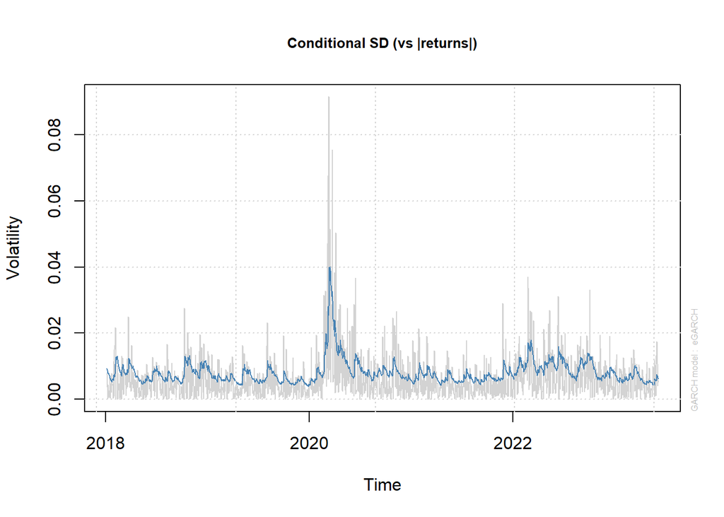

```r
plot(k.ar1egarch11, which = 3)
```

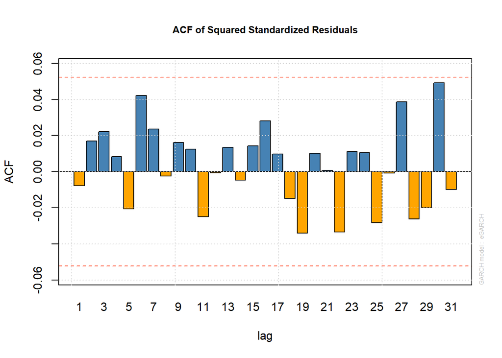

```r
plot(k.ar1egarch11, which = 11)
```

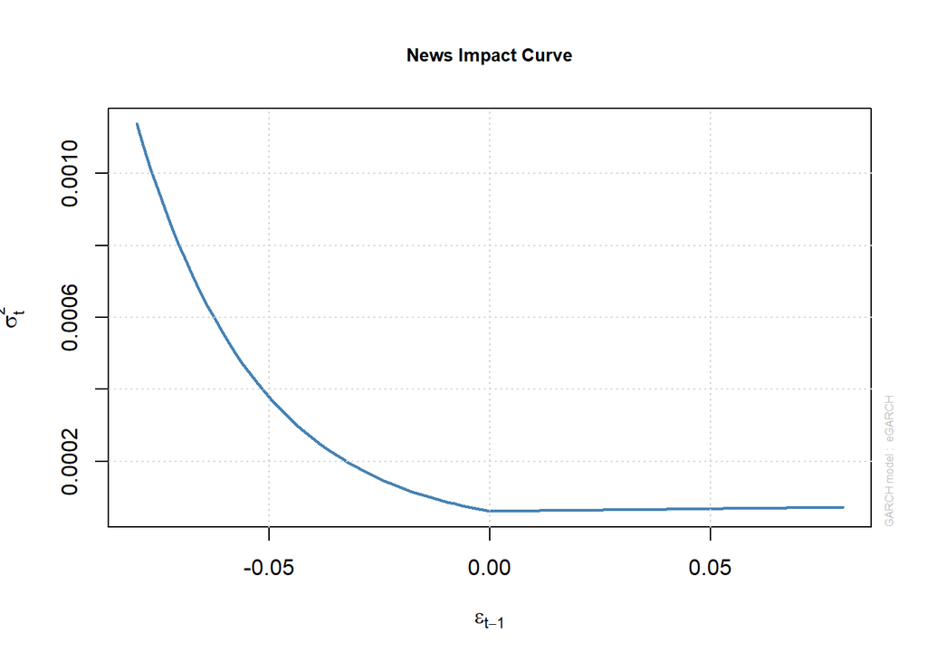

```r
plot(k.ar1egarch11, which = 12)
```

- The News Impact curve shows the asymmetric effect of shocks, since there is no effect when ϵt−1 is positive but a large effect when the shock is negative.

### AR(1)-EGARCH(1,1) without mu

```r
speca <- ugarchspec(# variance equation
  variance.model = list(model = "eGARCH",
                        garchOrder = c(1, 1)),
  mean.model = list(armaOrder = c(1, 0),
                    include.mean = FALSE),
  # assumed distribution of errors
  distribution.model = "norm")

# and estimate the model:

k.ar1egarch11a <- ugarchfit(spec = speca,
                           data = portfolio$PORTFOLIO_r)
```

Result:

```r
k.ar1egarch11a
```

[output not shown]

[output cut: 43 more lines]

```
## Negative Sign Bias  1.1549 0.24832
## Positive Sign Bias  1.6539 0.09837   *
## Joint Effect        6.1170 0.10605
##
##
## Adjusted Pearson Goodness-of-Fit Test:
## ------------------------------------
##   group statistic p-value(g-1)
## 1    20     38.34     0.005369
## 2    30     55.94     0.001922
## 3    40     63.95     0.007099
## 4    50     76.21     0.007670
##
##
## Elapsed time : 0.23294
```

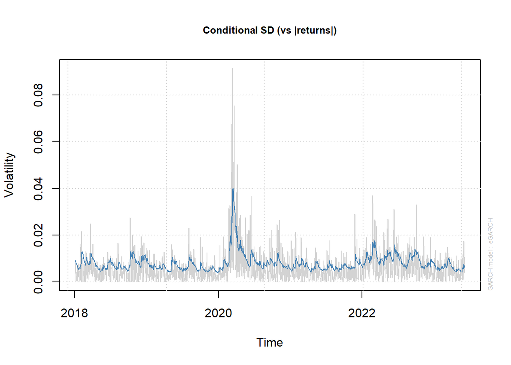

```r
plot(k.ar1egarch11a, which = 3)
```

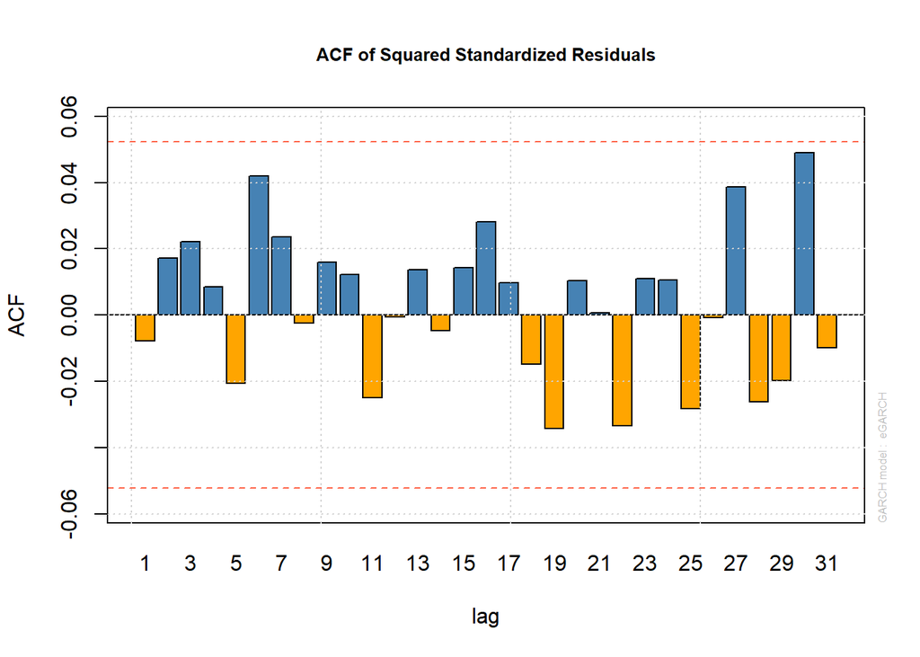

```r
plot(k.ar1egarch11a, which = 11)
```

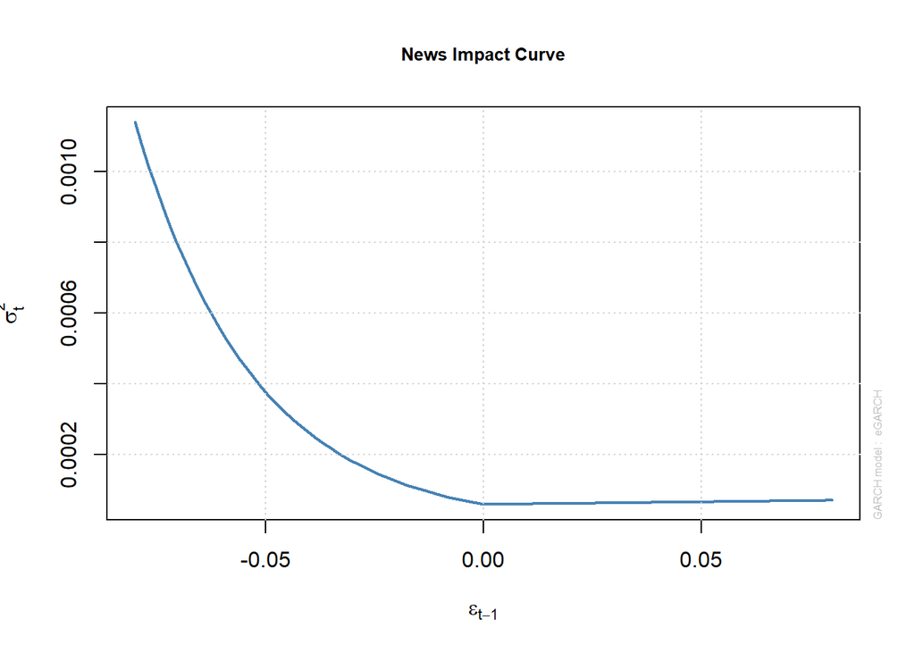

```r
plot(k.ar1egarch11a, which = 12)
```

- Almost the same result with the previous model, just without mu

## The GARCH-t model

### AR(1) - GARCH-st(1,1)

Let’s first define a model specification:

```r
spec <- ugarchspec(# variance equation
  variance.model = list(model = "sGARCH",
                        garchOrder = c(1, 1)),
  # mean equation
  mean.model = list(armaOrder = c(1, 0),
                    include.mean = TRUE),
  # assumed distribution of errors
  distribution.model = "std") # std = t-Student


# Then, estimate the model:

k.ar1garcht11 <- ugarchfit(spec = spec,
                           data = portfolio$PORTFOLIO_r)
# Result:
k.ar1garcht11
```

```
##
## *---------------------------------*
## *          GARCH Model Fit        *
## *---------------------------------*
##
## Conditional Variance Dynamics
## -----------------------------------
## GARCH Model  : sGARCH(1,1)
## Mean Model   : ARFIMA(1,0,0)
## Distribution : std
##
## Optimal Parameters
## ------------------------------------
##         Estimate  Std. Error  t value Pr(>|t|)
## mu      0.000560    0.000214   2.6201 0.008790
## ar1     0.173817    0.026846   6.4747 0.000000
## omega   0.000002    0.000002   1.2684 0.204652
## alpha1  0.109673    0.027153   4.0391 0.000054
## beta1   0.860206    0.031457  27.3457 0.000000
## shape   6.011503    0.996770   6.0310 0.000000
##
## Robust Standard Errors:
##         Estimate  Std. Error  t value Pr(>|t|)
## mu      0.000560    0.000183  3.06245 0.002195
## ar1     0.173817    0.025263  6.88026 0.000000
## omega   0.000002    0.000007  0.33123 0.740474
## alpha1  0.109673    0.073946  1.48315 0.138035
## beta1   0.860206    0.100560  8.55418 0.000000
## shape   6.011503    1.109711  5.41718 0.000000
##
## LogLikelihood : 4880.271
##
## Information Criteria
## ------------------------------------
##
## Akaike       -6.9090
## Bayes        -6.8866
## Shibata      -6.9090
## Hannan-Quinn -6.9006
##
```

[output cut: 43 more lines]

```
## Negative Sign Bias  2.5502 0.0108715  **
## Positive Sign Bias  2.0682 0.0388040  **
## Joint Effect       20.6113 0.0001268 ***
##
##
## Adjusted Pearson Goodness-of-Fit Test:
## ------------------------------------
##   group statistic p-value(g-1)
## 1    20     30.43      0.04656
## 2    30     43.61      0.03998
## 3    40     51.99      0.07969
## 4    50     56.36      0.21883
##
##
## Elapsed time : 0.4612579
```

- The shape paramters denotes the number of degrees of freedom for the t-Student distribution. In this case it equals to 6.011
- According to Ljung-Box Test, there is no autocorellation, and according to ARCH LM test, there is no ARCH effect.
- Nyblom stability test: if test statistic is greater than the critical value the null is rejected. The null hypothesis is about that all parameters or each parameter separately are stable over time (no structural breaks in the model). So here we reject the stability jointly (27 > 1.68), but cannot reject for any parameter (stat < 0.47), except omega.
- The Sign Bias Test verifies the null hypothesis if there is still some asymmetric reaction of variance of residuals to shocks. So the null is rejected the asymmetry has not been captured correctly in the estimated model.
- The Adjusted Pearson Goodness-of-Fit test statistics assess the adequacy of the GARCH model in capturing the characteristics of the data.

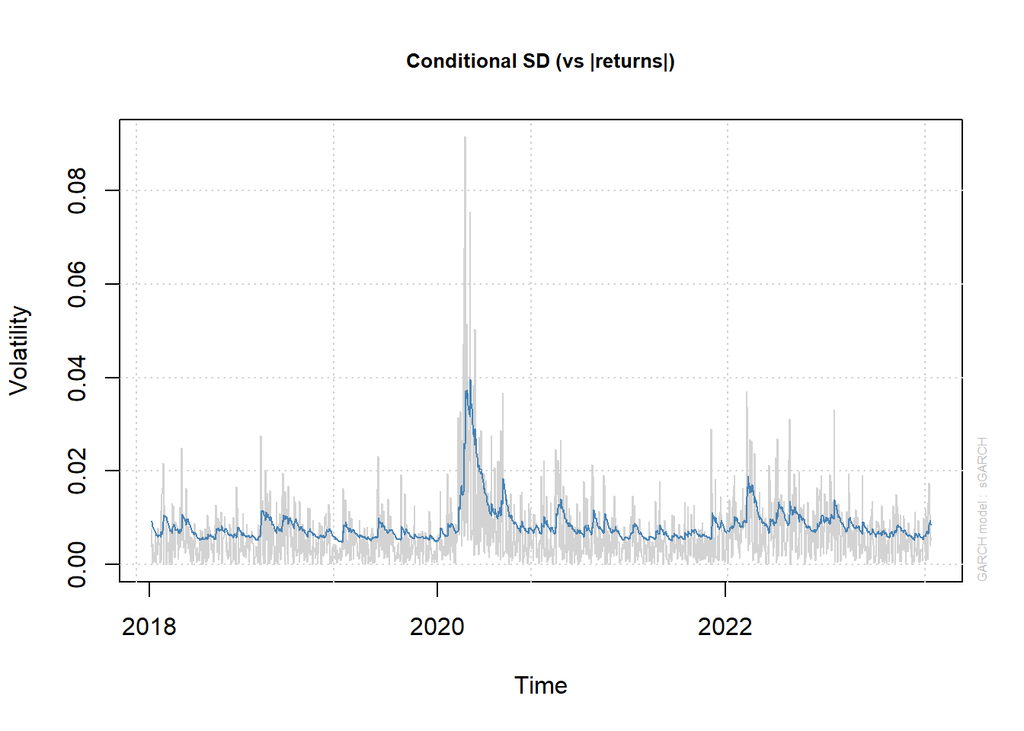

```r
plot(k.ar1garcht11, which = 3)
```

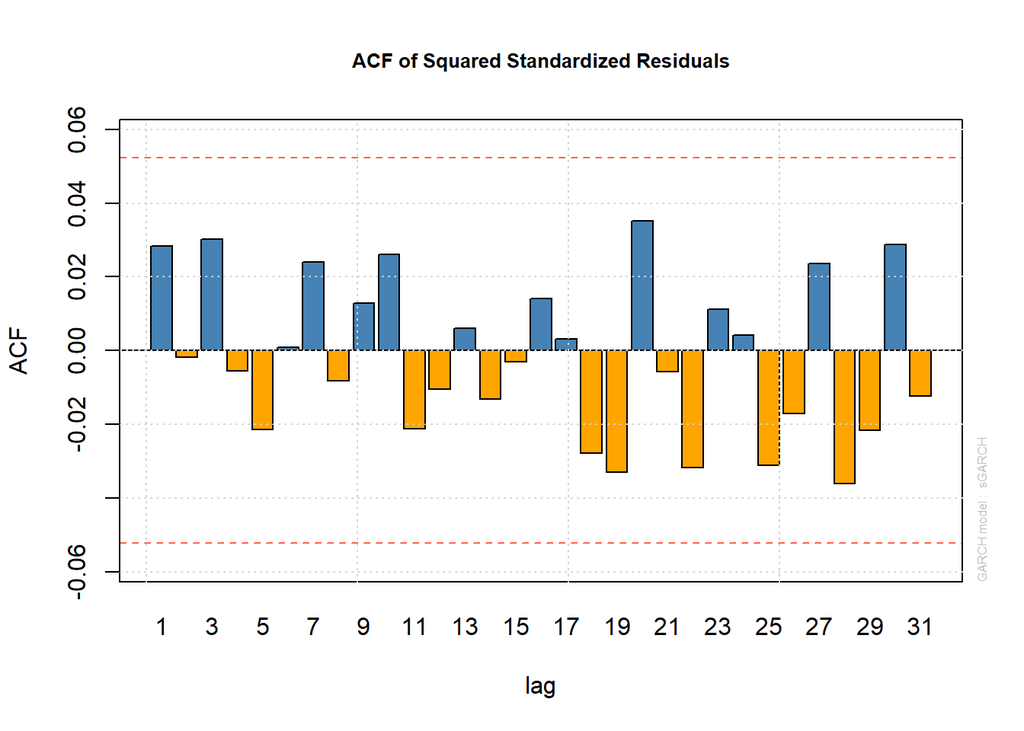

```r
plot(k.ar1garcht11, which = 11)
```

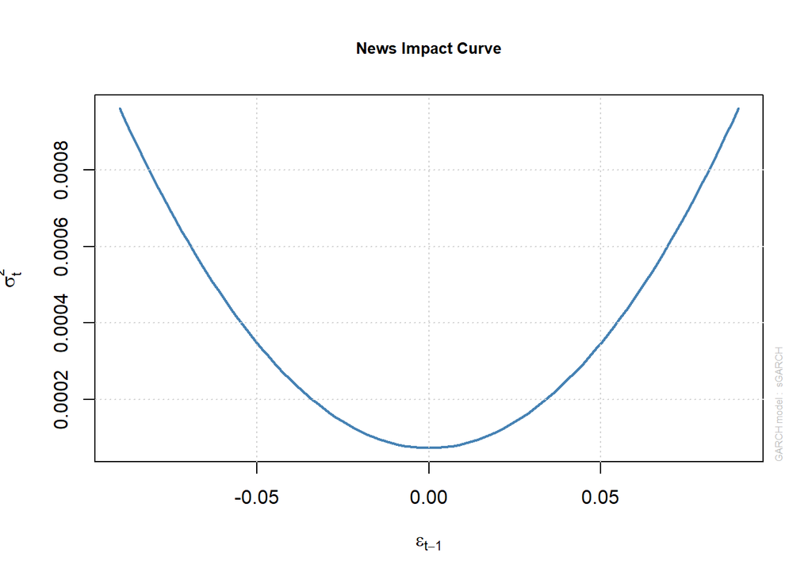

```r
plot(k.ar1garcht11, which = 12)
```

## The GARCH-in-Mean model

### AR(1)-GARCH-m(1,1)

Let’s first define a model specification:

```r
spec <- ugarchspec(# variance equation
  variance.model = list(model = "sGARCH",
                        # sGARCH = standard GARCH
                        garchOrder = c(1, 1)),
  # mean equation - lets turn on the intercept term
  mean.model = list(armaOrder = c(1, 0),
                    include.mean = TRUE,
                    # we add an element to the mean equation,
                    # which can be either stdev (archpow 1)
                    # or var (archpow=2)
                    archm = TRUE, archpow = 1),
  # assumed distribution of errors
  distribution.model = "norm")

# Then, we can estimate the model:

k.ar1garchm11 <- ugarchfit(spec = spec,
                           data = portfolio$PORTFOLIO_r)

# Let's examine the results:

k.ar1garchm11
```

```
##
## *---------------------------------*
## *          GARCH Model Fit        *
## *---------------------------------*
##
## Conditional Variance Dynamics
## -----------------------------------
## GARCH Model  : sGARCH(1,1)
## Mean Model   : ARFIMA(1,0,0)
## Distribution : norm
##
## Optimal Parameters
## ------------------------------------
##         Estimate  Std. Error  t value Pr(>|t|)
## mu     -0.001780    0.000933  -1.9078 0.056412
## ar1     0.193074    0.028598   6.7514 0.000000
## archm   0.319902    0.128709   2.4855 0.012938
## omega   0.000003    0.000002   1.8058 0.070945
## alpha1  0.118846    0.013694   8.6786 0.000000
## beta1   0.835239    0.006195 134.8263 0.000000
##
## Robust Standard Errors:
##         Estimate  Std. Error  t value Pr(>|t|)
## mu     -0.001780    0.001527 -1.16616 0.243551
## ar1     0.193074    0.028216  6.84270 0.000000
## archm   0.319902    0.174589  1.83231 0.066905
## omega   0.000003    0.000009  0.37088 0.710730
## alpha1  0.118846    0.037333  3.18342 0.001455
## beta1   0.835239    0.076801 10.87532 0.000000
##
## LogLikelihood : 4851.952
##
## Information Criteria
## ------------------------------------
##
## Akaike       -6.8688
## Bayes        -6.8465
## Shibata      -6.8689
## Hannan-Quinn -6.8605
##
```

[output cut: 43 more lines]

```
## Negative Sign Bias  2.1164 0.0344853  **
## Positive Sign Bias  1.7576 0.0790373   *
## Joint Effect       17.0810 0.0006801 ***
##
##
## Adjusted Pearson Goodness-of-Fit Test:
## ------------------------------------
##   group statistic p-value(g-1)
## 1    20     51.07   0.00009107
## 2    30     61.64   0.00038485
## 3    40     74.73   0.00049985
## 4    50     89.96   0.00032649
##
##
## Elapsed time : 0.813431
```

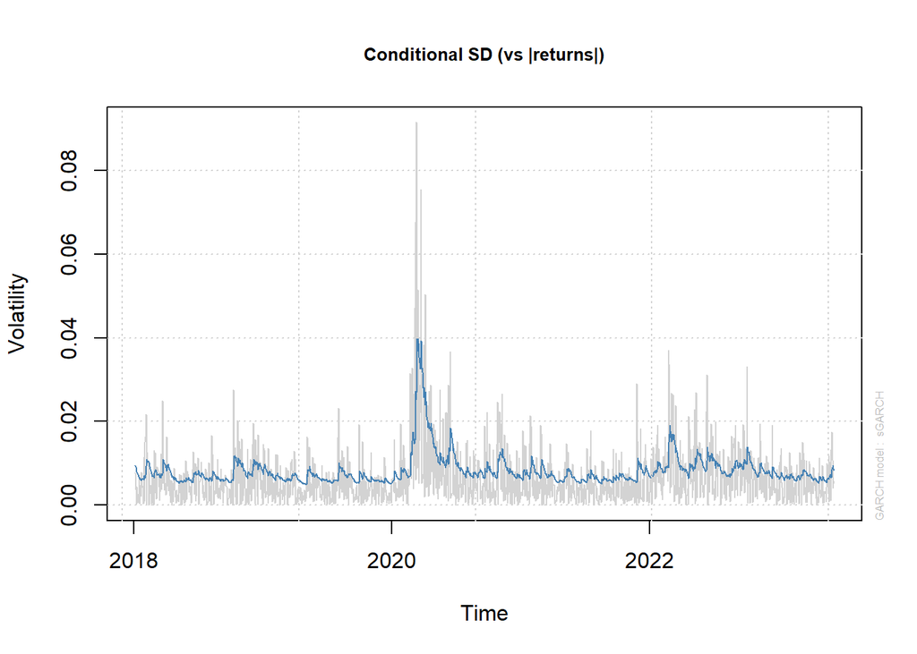

```r
plot(k.ar1garchm11, which = 3)
```

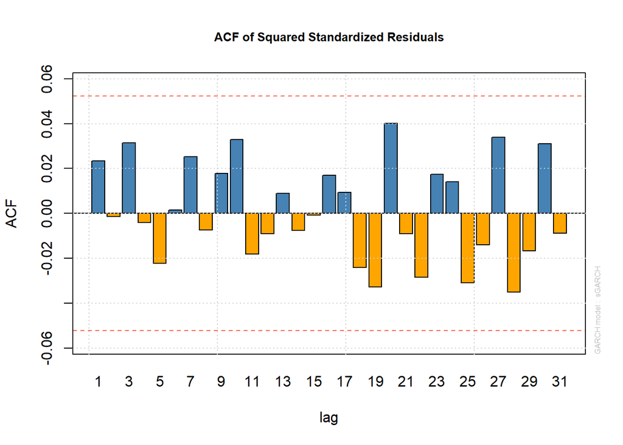

```r
plot(k.ar1garchm11, which = 11)
```

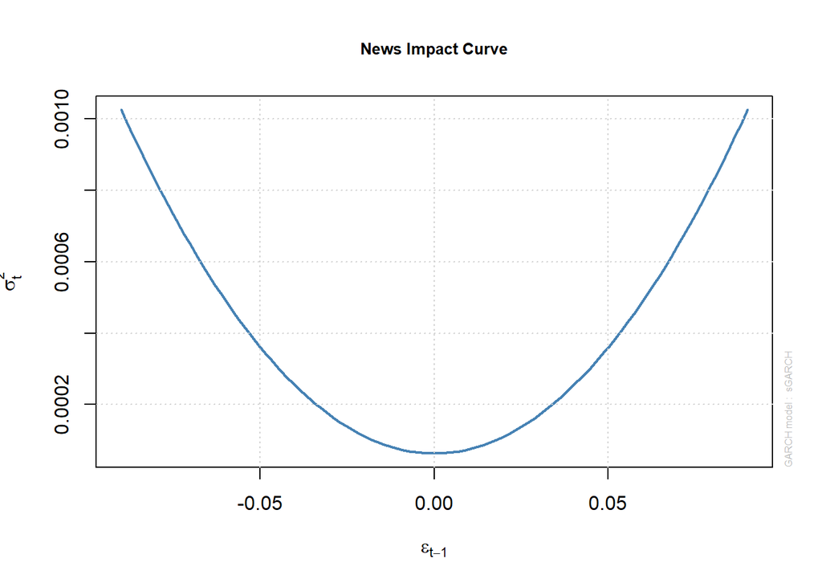

```r
plot(k.ar1garchm11, which = 12)
```

**mu** is insignificant, let’s remove mu.

### AR(1)-GARCH-m(1,1) without mu

```r
spec <- ugarchspec(# variance equation
  variance.model = list(model = "sGARCH",
                        # sGARCH = standard GARCH
                        garchOrder = c(1, 1)),
  # mean equation - lets turn on the intercept term
  mean.model = list(armaOrder = c(1, 0),
                    include.mean = FALSE,
                    # we add an element to the mean equation,
                    # which can be either stdev (archpow 1)
                    # or var (archpow=2)
                    archm = TRUE, archpow = 1),
  # assumed distribution of errors
  distribution.model = "norm")

# Model estimation:

k.ar1garchm11a <- ugarchfit(spec = spec,
                           data = portfolio$PORTFOLIO_r)

# Model summary:

k.ar1garchm11a
```

```
##
## *---------------------------------*
## *          GARCH Model Fit        *
## *---------------------------------*
##
## Conditional Variance Dynamics
## -----------------------------------
## GARCH Model  : sGARCH(1,1)
## Mean Model   : ARFIMA(1,0,0)
## Distribution : norm
##
## Optimal Parameters
## ------------------------------------
##         Estimate  Std. Error  t value Pr(>|t|)
## ar1     0.191601    0.028677   6.6814 0.000000
## archm   0.082785    0.032230   2.5686 0.010212
## omega   0.000003    0.000002   1.8285 0.067469
## alpha1  0.119873    0.013118   9.1378 0.000000
## beta1   0.834961    0.008826  94.5992 0.000000
##
## Robust Standard Errors:
##         Estimate  Std. Error  t value Pr(>|t|)
## ar1     0.191601    0.028270  6.77759 0.000000
## archm   0.082785    0.030613  2.70421 0.006847
## omega   0.000003    0.000009  0.35187 0.724936
## alpha1  0.119873    0.045047  2.66108 0.007789
## beta1   0.834961    0.073514 11.35793 0.000000
##
## LogLikelihood : 4850.184
##
## Information Criteria
## ------------------------------------
##
## Akaike       -6.8677
## Bayes        -6.8491
## Shibata      -6.8678
## Hannan-Quinn -6.8608
##
## Weighted Ljung-Box Test on Standardized Residuals
## ------------------------------------
```

[output cut: 40 more lines]

```
## Negative Sign Bias  2.2812 0.0226859  **
## Positive Sign Bias  1.8732 0.0612550   *
## Joint Effect       18.6260 0.0003267 ***
##
##
## Adjusted Pearson Goodness-of-Fit Test:
## ------------------------------------
##   group statistic p-value(g-1)
## 1    20     44.46    0.0008142
## 2    30     62.15    0.0003315
## 3    40     74.67    0.0005074
## 4    50     84.50    0.0012218
##
##
## Elapsed time : 0.68538
```

- Except omega, all parameters are significant.
- There is no ARCH effect.
- Ljung-Box Test shows no autocorrelation.
- The Nyblom stability test verifies the null that all parameters or each parameter separately are stable over time (no structural breaks in the model). If test statistic is smaller than the critical value, the null isn’t rejected.

So here we cannot reject the stability jointly (1.093 < 1.68 1.68), and for any parameter (stat < 0.47).

- The Sign Bias Test verifies the null hypothesis if there is still some asymmetric reaction of variance of residuals to shocks. So the null is rejected, the asymmetry has not been captured correctly in the estimated model.
- The Adjusted Pearson Goodness-of-Fit test statistics assess the adequacy of the GARCH model in capturing the characteristics of the data. With p_value < 0.05, we reject the null hypothesis.

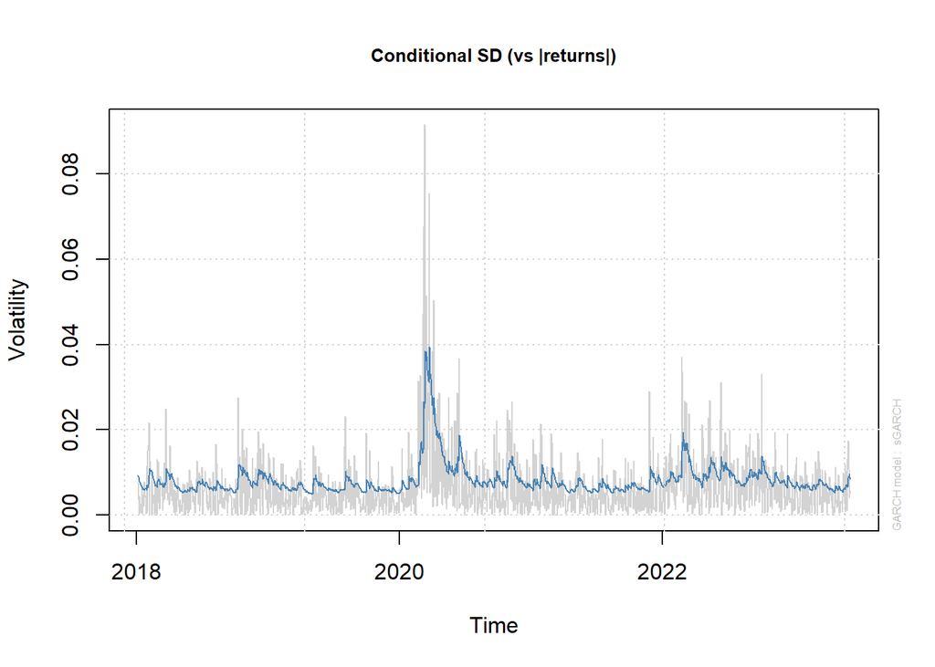

```r
plot(k.ar1garchm11a, which = 3)
```

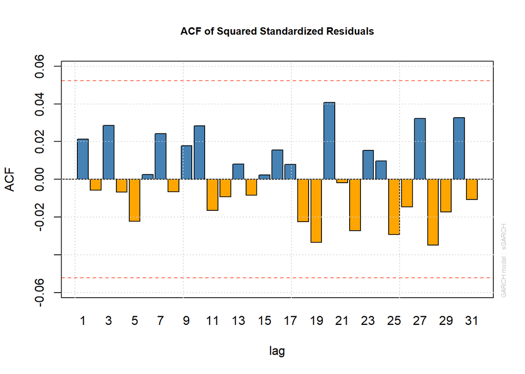

```r
plot(k.ar1garchm11a, which = 11)
```

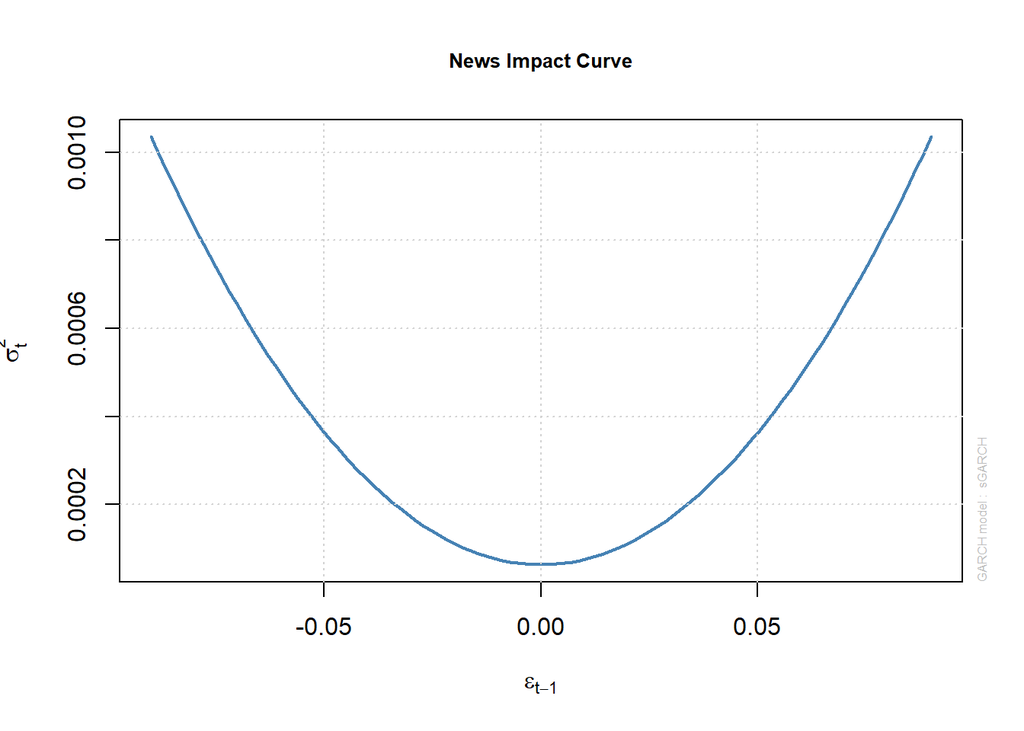

```r
plot(k.ar1garchm11a, which = 12)
```

## The EGARCH in mean-t model

### AR(1)-EGARCH-m-st(1,1)

Let’s first define the model specification:

```r
spec <- ugarchspec(# variance equation
  variance.model = list(model = "eGARCH",
                        garchOrder = c(1, 1)),
  # mean equation
  mean.model = list(armaOrder = c(1, 0),
                    include.mean = TRUE,
                    archm = TRUE, archpow = 1),
  # assumed distribution of errors
  distribution.model = "std") # std = t-Student

# Now, let's estimate the model:

k.ar1egarchmt11 <- ugarchfit(spec = spec,
                             data = portfolio$PORTFOLIO_r)

# The model summary:

k.ar1egarchmt11
```

```
##
## *---------------------------------*
## *          GARCH Model Fit        *
## *---------------------------------*
##
## Conditional Variance Dynamics
## -----------------------------------
## GARCH Model  : eGARCH(1,1)
## Mean Model   : ARFIMA(1,0,0)
## Distribution : std
##
## Optimal Parameters
## ------------------------------------
##         Estimate  Std. Error   t value Pr(>|t|)
## mu     -0.001174    0.000318   -3.6877 0.000226
## ar1     0.203165    0.027461    7.3984 0.000000
## archm   0.206302    0.050938    4.0501 0.000051
## omega  -0.336497    0.002514 -133.8407 0.000000
## alpha1 -0.138122    0.017643   -7.8286 0.000000
## beta1   0.965948    0.000545 1772.9707 0.000000
## gamma1  0.139508    0.008291   16.8259 0.000000
## shape   7.161874    1.357429    5.2761 0.000000
##
## Robust Standard Errors:
##         Estimate  Std. Error   t value Pr(>|t|)
## mu     -0.001174    0.000218   -5.3788 0.000000
## ar1     0.203165    0.026358    7.7080 0.000000
## archm   0.206302    0.043256    4.7693 0.000002
## omega  -0.336497    0.008363  -40.2369 0.000000
## alpha1 -0.138122    0.022047   -6.2650 0.000000
## beta1   0.965948    0.000615 1571.4044 0.000000
## gamma1  0.139508    0.008879   15.7118 0.000000
## shape   7.161874    1.306636    5.4812 0.000000
##
## LogLikelihood : 4905.565
##
## Information Criteria
## ------------------------------------
##
## Akaike       -6.9420
```

[output cut: 49 more lines]

```
## Negative Sign Bias  0.9543 0.3401
## Positive Sign Bias  1.3440 0.1792
## Joint Effect        5.6673 0.1290
##
##
## Adjusted Pearson Goodness-of-Fit Test:
## ------------------------------------
##   group statistic p-value(g-1)
## 1    20     21.16      0.32794
## 2    30     39.35      0.09506
## 3    40     40.03      0.42436
## 4    50     56.51      0.21501
##
##
## Elapsed time : 0.939199
```

- All parameteres are significant.
- There is no Autocorellation - Ljung-Box Test
- No Arch effect
- The Nyblom stability test verifies the null that all parameters or each parameter separately are stable over time (no structural breaks in the model). If test statistic is smaller than the critical value, the null isn’t rejected. So here we cannot reject the stability jointly (1.86 < 2.11), and for other parameter, except omega and beta1 (stat < 0.47)
- The Sign Bias Test verifies the null hypothesis if there is still some asymmetric reaction of variance of residuals to shocks. If null not rejected - the asymmetry has been captured correctly in the estimated model. The model does not require higher order.
- The Adjusted Pearson Goodness-of-Fit test statistics assess the adequacy of the GARCH model in capturing the characteristics of the data. With p_value > 0.05, we do not reject the null hypothesis.

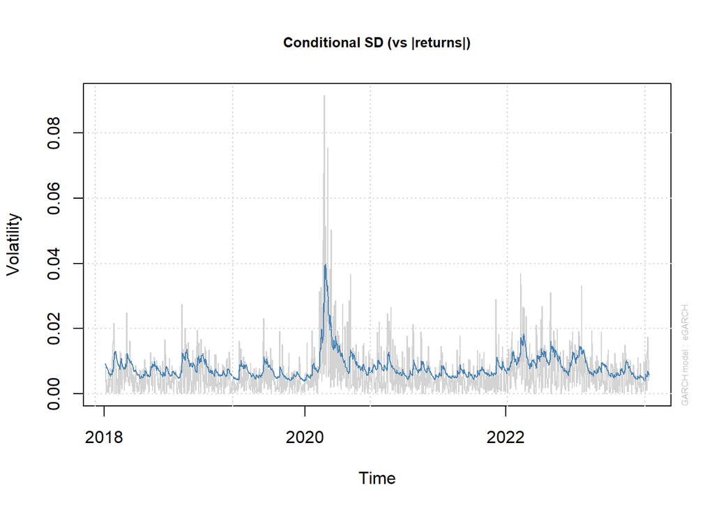

```r
plot(k.ar1egarchmt11, which = 3)
```

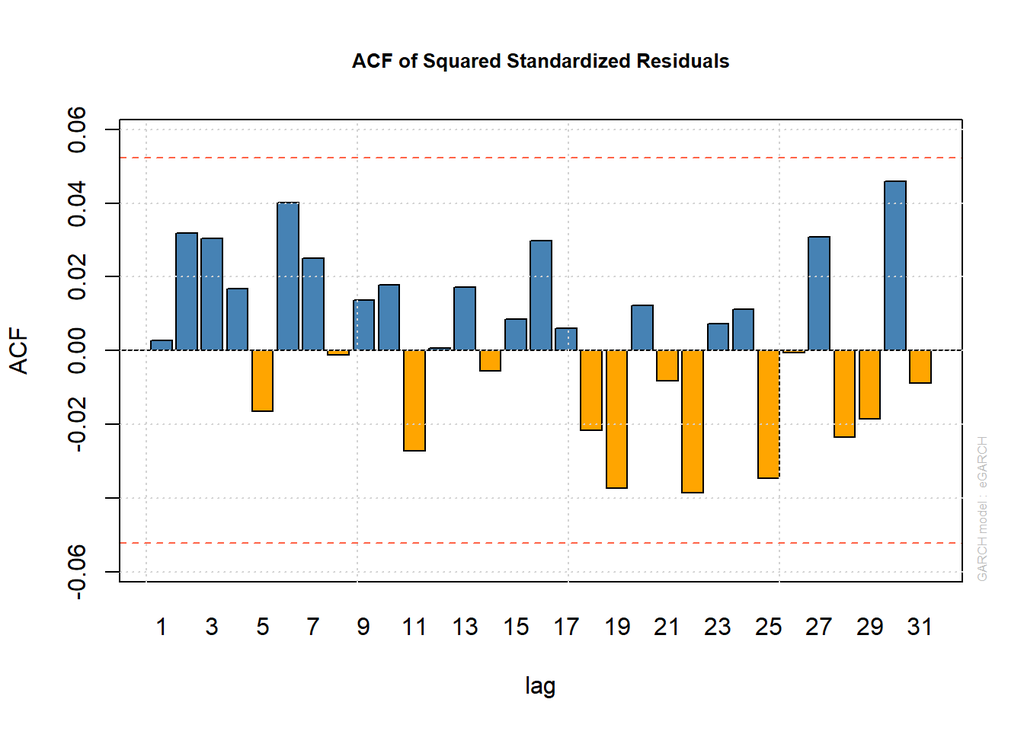

```r
plot(k.ar1egarchmt11, which = 11)
```

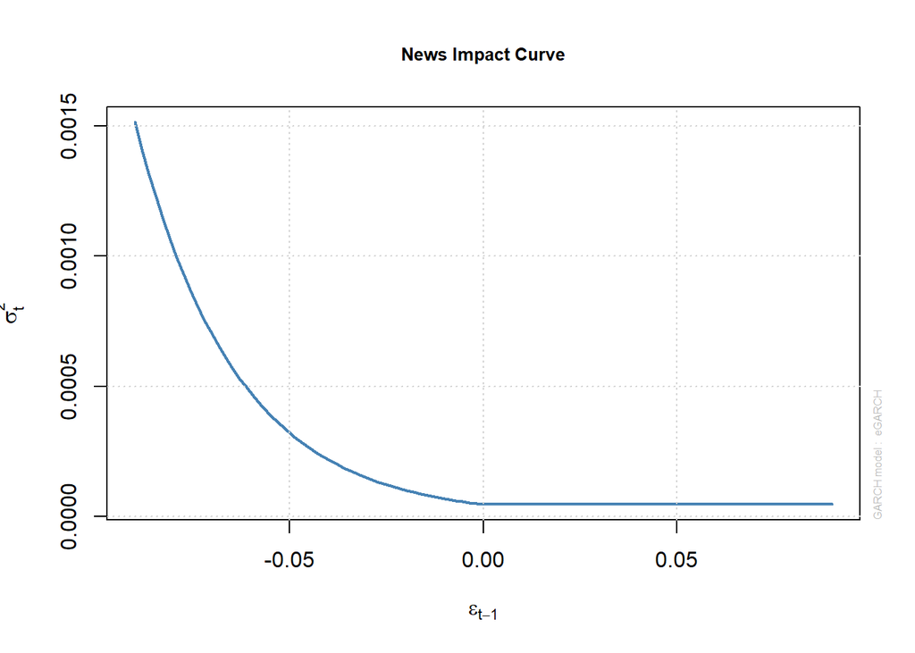

```r
plot(k.ar1egarchmt11, which = 12)
```

# Comparison

```r
compare_ICs_ugarchfit(c("k.ar1egarch11",
                        "k.ar1egarch11a",
                        "k.ar1garcht11",
                        "k.ar1garchm11",
                        "k.ar1garchm11a",
                        "k.ar1egarchmt11"))
```

```
## $ICs
##      Akaike     Bayes   Shibata Hannan.Quinn           model
## 1 -6.913567 -6.891234 -6.913603    -6.905222   k.ar1egarch11
## 2 -6.914977 -6.896366 -6.915002    -6.908022  k.ar1egarch11a
## 3 -6.908959 -6.886626 -6.908995    -6.900614   k.ar1garcht11
## 4 -6.868819 -6.846485 -6.868855    -6.860473   k.ar1garchm11
## 5 -6.867730 -6.849119 -6.867755    -6.860776  k.ar1garchm11a
## 6 -6.941978 -6.912200 -6.942042    -6.930851 k.ar1egarchmt11
##
## $which.min
##       Akaike        Bayes      Shibata Hannan.Quinn
##            6            6            6            6
```

According to the comparison, last model, *AR(1)-EGARCH-m-st(1,1)* is the best model.

Let’s turn page to the new chapter 🍀

# VaR (Value at risk)

## VaR In-Sample period

Choosing in-sample period:

```r
portfolio_IS <- portfolio["2018/2021",]
head(portfolio_IS)
```

```
##              SP500      DAX   WIG20 KOSPI200   NKK225       SP500_r
## 2018-01-05 2743.15 13319.64 2529.55  2497.52 23714.53  0.0014018292
## 2018-01-08 2747.71 13367.78 2548.61  2513.28 23714.53  0.0003321928
## 2018-01-09 2751.29 13385.59 2528.38  2510.23 23849.99  0.0002604167
## 2018-01-10 2748.23 13281.34 2511.27  2499.75 23788.20 -0.0002225692
## 2018-01-11 2767.56 13202.90 2534.56  2487.91 23710.43  0.0014018052
## 2018-01-12 2786.24 13245.03 2539.29  2496.42 23653.82  0.0013453853
##                    DAX_r       WIG20_r       KOSPI_r      NKK225_r
## 2018-01-05  0.0022916695 -0.0002860123  0.0025028631  0.0017636388
## 2018-01-08  0.0007215486  0.0015013382  0.0012580867  0.0000000000
## 2018-01-09  0.0002662778 -0.0015938662 -0.0002428581  0.0011391715
## 2018-01-10 -0.0015637425 -0.0013580360 -0.0008367311 -0.0005188277
## 2018-01-11 -0.0011846998  0.0018462901 -0.0009495453 -0.0006549247
## 2018-01-12  0.0006371753  0.0003728925  0.0006829410 -0.0004780823
##              PORTFOLIO_r
## 2018-01-05  0.0076739882
## 2018-01-08  0.0038131663
## 2018-01-09 -0.0001708583
## 2018-01-10 -0.0044999066
## 2018-01-11  0.0004589255
## 2018-01-12  0.0025603117
```

Standardization of returns

```r
portfolio_IS$rstd <- (portfolio_IS$PORTFOLIO_r - mean(portfolio_IS$PORTFOLIO_r, na.rm = T)) /
  sd(portfolio_IS$PORTFOLIO_r ,na.rm = T)

tail(portfolio_IS)
```

```
##              SP500      DAX   WIG20 KOSPI200   NKK225       SP500_r
## 2021-12-24 4725.79 15756.31 2225.80  3012.43 28782.59  0.0000000000
## 2021-12-27 4791.19 15835.25 2226.24  2999.55 28676.46  0.0027488103
## 2021-12-28 4786.35 15963.70 2252.43  3020.24 29069.16 -0.0002021331
## 2021-12-29 4793.06 15852.25 2260.70  2993.29 28906.88  0.0002801827
## 2021-12-30 4778.73 15884.86 2266.92  2977.65 28791.71 -0.0005988468
## 2021-12-31 4766.18 15884.86 2266.92  2977.65 28791.71 -0.0005259269
##                    DAX_r       WIG20_r       KOSPI_r      NKK225_r
## 2021-12-24  0.0000000000 0.00000000000  0.0009489919 -0.0001096196
## 2021-12-27  0.0009995150 0.00003953244 -0.0008569569 -0.0007388227
## 2021-12-28  0.0016157879 0.00233911394  0.0013748042  0.0027202482
## 2021-12-29 -0.0014011922 0.00073297328 -0.0017926363 -0.0011196379
## 2021-12-30  0.0004110061 0.00054951643 -0.0010477436 -0.0007984261
## 2021-12-31  0.0000000000 0.00000000000  0.0000000000  0.0000000000
##              PORTFOLIO_r        rstd
## 2021-12-24  0.0008393723  0.06822737
## 2021-12-27  0.0021920782  0.21210415
## 2021-12-28  0.0078478212  0.81366143
## 2021-12-29 -0.0033003104 -0.37207840
## 2021-12-30 -0.0014844940 -0.17894417
## 2021-12-31 -0.0005259269 -0.07698886
```

```r
basicStats(portfolio_IS$rstd)
```

```
##                    rstd
## nobs        1038.000000
## NAs            0.000000
## Minimum       -9.754867
## Maximum        8.001785
## 1. Quartile   -0.422970
## 3. Quartile    0.477290
## Mean           0.000000
## Median         0.041049
## Sum            0.000000
## SE Mean        0.031039
## LCL Mean      -0.060906
## UCL Mean       0.060906
## Variance       1.000000
## Stdev          1.000000
## Skewness      -1.098052
## Kurtosis      17.358553
```

Negative skewness, and high kurtosis

1% empirical quantile

```r
q01 <- quantile(portfolio_IS$rstd, 0.01, na.rm = T)
q01
```

```
##        1%
## -3.075256
```

**AR(1)-EGARCH-m-st(1,1) - VaR**

```r
spec <- ugarchspec(# variance equation
  variance.model = list(model = "eGARCH",
                        garchOrder = c(1, 1)),
  # mean equation
  mean.model = list(armaOrder = c(1, 0),
                    include.mean = TRUE,
                    archm = TRUE, archpow = 1),
  # assumed distribution of errors
  distribution.model = "std") # std = t-Student

#Estimating
portfolio_IS.ar1egarchmt11 <- ugarchfit(spec = spec, data = portfolio_IS$PORTFOLIO_r)
```

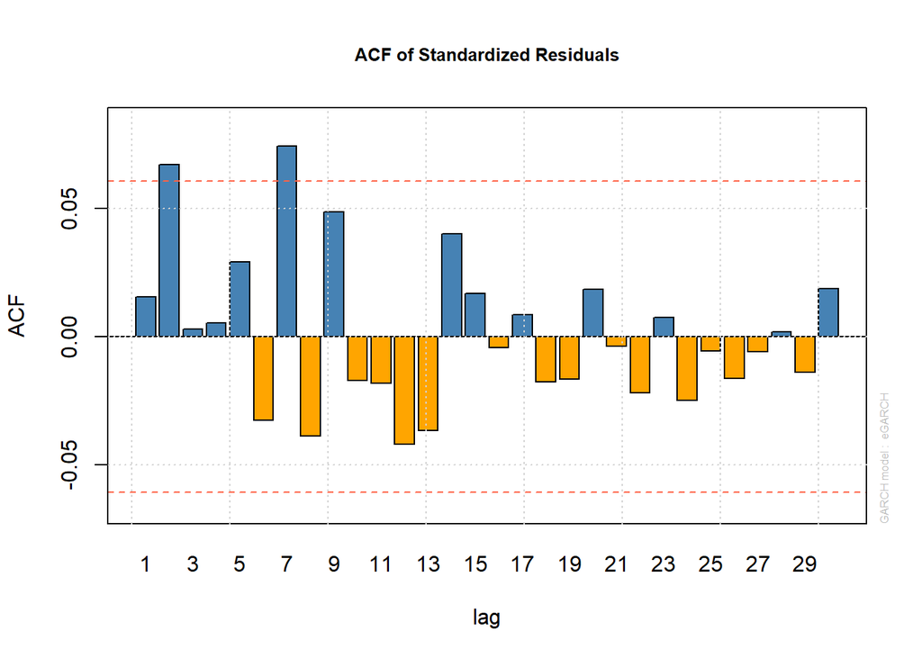

```r
# Plot
plot(portfolio_IS.ar1egarchmt11, which = 10)
```

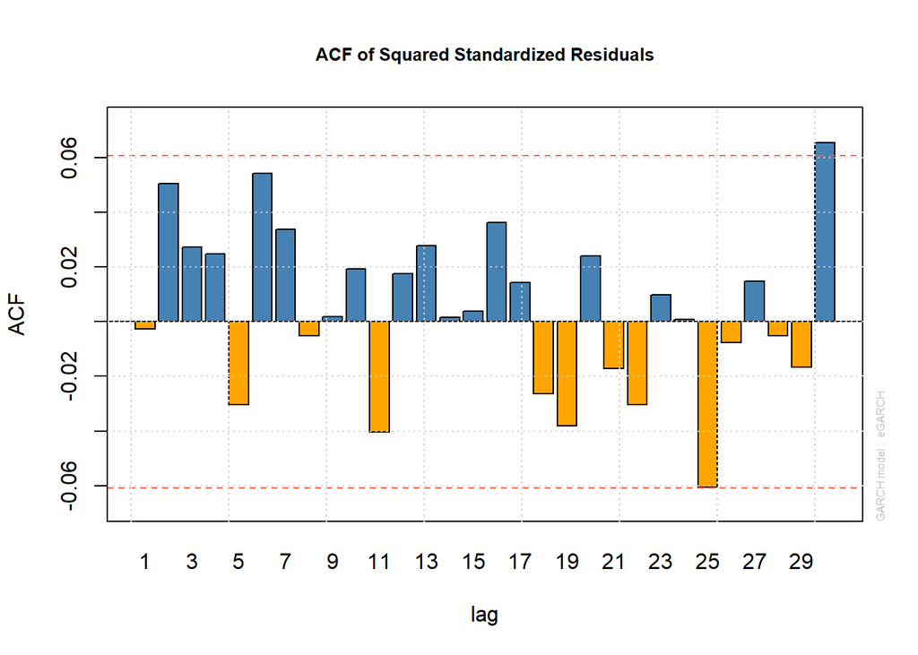

```r
plot(portfolio_IS.ar1egarchmt11, which = 11)
```

**Fitting model**

```r
head(portfolio_IS.ar1egarchmt11@fit$sigma)
```

```
## [1] 0.009533382 0.008897148 0.008331010 0.008049353 0.008322997 0.007814897
```

**Calculating value-at-risk (VaR):**

```r
portfolio_IS$VaR <- q01 * portfolio_IS.ar1egarchmt11@fit$sigma
tail(portfolio_IS)
```

```
##              SP500      DAX   WIG20 KOSPI200   NKK225       SP500_r
## 2021-12-24 4725.79 15756.31 2225.80  3012.43 28782.59  0.0000000000
## 2021-12-27 4791.19 15835.25 2226.24  2999.55 28676.46  0.0027488103
## 2021-12-28 4786.35 15963.70 2252.43  3020.24 29069.16 -0.0002021331
## 2021-12-29 4793.06 15852.25 2260.70  2993.29 28906.88  0.0002801827
## 2021-12-30 4778.73 15884.86 2266.92  2977.65 28791.71 -0.0005988468
## 2021-12-31 4766.18 15884.86 2266.92  2977.65 28791.71 -0.0005259269
##                    DAX_r       WIG20_r       KOSPI_r      NKK225_r
## 2021-12-24  0.0000000000 0.00000000000  0.0009489919 -0.0001096196
## 2021-12-27  0.0009995150 0.00003953244 -0.0008569569 -0.0007388227
## 2021-12-28  0.0016157879 0.00233911394  0.0013748042  0.0027202482
## 2021-12-29 -0.0014011922 0.00073297328 -0.0017926363 -0.0011196379
## 2021-12-30  0.0004110061 0.00054951643 -0.0010477436 -0.0007984261
## 2021-12-31  0.0000000000 0.00000000000  0.0000000000  0.0000000000
##              PORTFOLIO_r        rstd         VaR
## 2021-12-24  0.0008393723  0.06822737 -0.02602691
## 2021-12-27  0.0021920782  0.21210415 -0.02495186
## 2021-12-28  0.0078478212  0.81366143 -0.02344870
## 2021-12-29 -0.0033003104 -0.37207840 -0.02206894
## 2021-12-30 -0.0014844940 -0.17894417 -0.02317906
## 2021-12-31 -0.0005259269 -0.07698886 -0.02249138
```

```r
head(portfolio_IS)
```

```
##              SP500      DAX   WIG20 KOSPI200   NKK225       SP500_r
## 2018-01-05 2743.15 13319.64 2529.55  2497.52 23714.53  0.0014018292
## 2018-01-08 2747.71 13367.78 2548.61  2513.28 23714.53  0.0003321928
## 2018-01-09 2751.29 13385.59 2528.38  2510.23 23849.99  0.0002604167
## 2018-01-10 2748.23 13281.34 2511.27  2499.75 23788.20 -0.0002225692
## 2018-01-11 2767.56 13202.90 2534.56  2487.91 23710.43  0.0014018052
## 2018-01-12 2786.24 13245.03 2539.29  2496.42 23653.82  0.0013453853
##                    DAX_r       WIG20_r       KOSPI_r      NKK225_r
## 2018-01-05  0.0022916695 -0.0002860123  0.0025028631  0.0017636388
## 2018-01-08  0.0007215486  0.0015013382  0.0012580867  0.0000000000
## 2018-01-09  0.0002662778 -0.0015938662 -0.0002428581  0.0011391715
## 2018-01-10 -0.0015637425 -0.0013580360 -0.0008367311 -0.0005188277
## 2018-01-11 -0.0011846998  0.0018462901 -0.0009495453 -0.0006549247
## 2018-01-12  0.0006371753  0.0003728925  0.0006829410 -0.0004780823
##              PORTFOLIO_r        rstd         VaR
## 2018-01-05  0.0076739882  0.79517218 -0.02931758
## 2018-01-08  0.0038131663  0.38452665 -0.02736100
## 2018-01-09 -0.0001708583 -0.03922298 -0.02561998
## 2018-01-10 -0.0044999066 -0.49967009 -0.02475382
## 2018-01-11  0.0004589255  0.02776222 -0.02559534
## 2018-01-12  0.0025603117  0.25127028 -0.02403281
```

Plot of returns vs value-at-risk

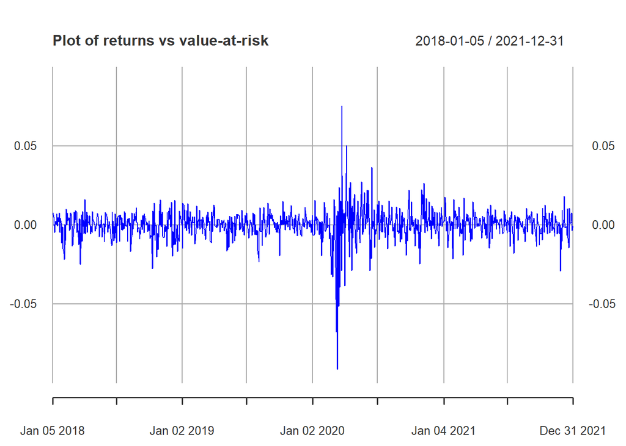

```r
plot(portfolio_IS$PORTFOLIO_r,
     col = "blue", lwd = 1, type = 'l',
     ylim = c(-0.1, 0.1),
     main = "Plot of returns vs value-at-risk")
abline(h = 0, lty = 2)
```

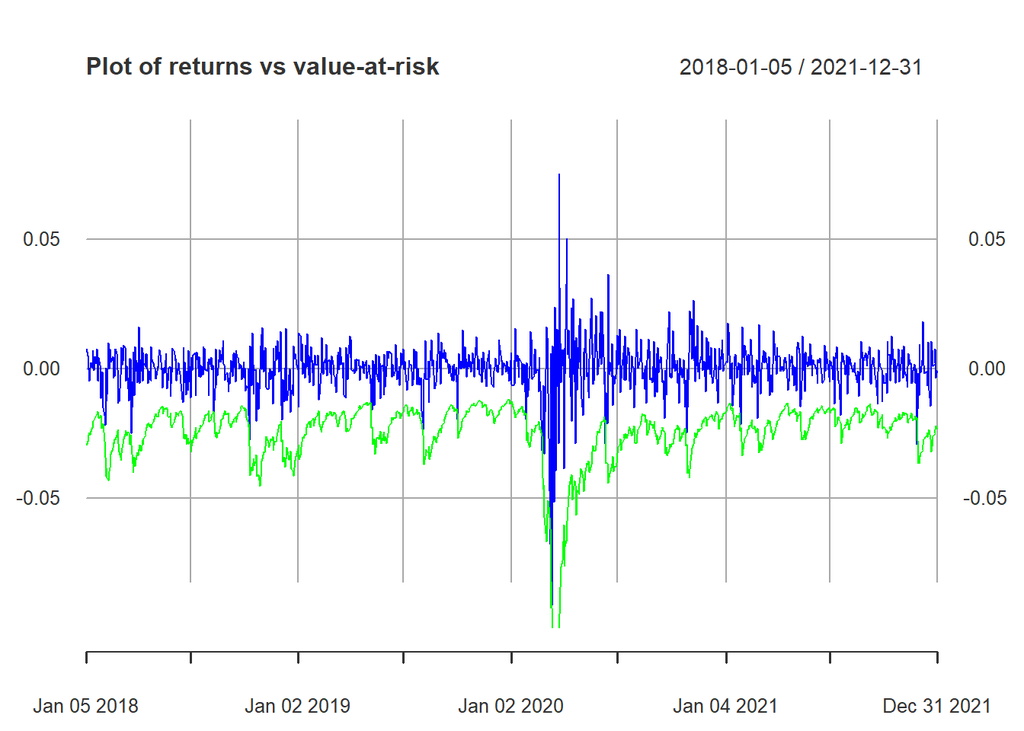

```r
lines(portfolio_IS$VaR, type = 'l', col = "green")
```

## VaR Out-of-sample period

Choosing VaR in the Oot-of-Sample(OS) period:

```r
portfolio_OS <- portfolio["2022/2022",]
head(portfolio_OS)
```

```
##              SP500      DAX   WIG20 KOSPI200   NKK225       SP500_r
## 2022-01-03 4796.56 16020.73 2286.50  2988.77 28791.71  0.0012707648
## 2022-01-04 4793.54 16152.61 2300.68  2989.24 29301.79 -0.0001259641
## 2022-01-05 4700.58 16271.75 2310.97  2953.97 29332.16 -0.0039166529
## 2022-01-06 4696.05 16052.03 2310.97  2920.53 28487.87 -0.0001928467
## 2022-01-07 4677.03 15947.74 2311.93  2954.89 28478.56 -0.0008116882
## 2022-01-10 4670.29 15768.27 2291.23  2926.72 28478.56 -0.0002884141
##                   DAX_r        WIG20_r        KOSPI_r       NKK225_r
## 2022-01-03  0.001703412  0.00172003643  0.00074550654  0.00000000000
## 2022-01-04  0.001639626  0.00123649346  0.00003144859  0.00351222156
## 2022-01-05  0.001469761  0.00089252368 -0.00237382923  0.00020718374
## 2022-01-06 -0.002719027  0.00000000000 -0.00227698434 -0.00584122847
## 2022-01-07 -0.001303639  0.00008306474  0.00233926369 -0.00006537183
## 2022-01-10 -0.002263496 -0.00179877645 -0.00191581662  0.00000000000
##              PORTFOLIO_r
## 2022-01-03  0.0054397201
## 2022-01-04  0.0062938256
## 2022-01-05 -0.0037210133
## 2022-01-06 -0.0110300870
## 2022-01-07  0.0002416289
## 2022-01-10 -0.0062665027
```

Standardization of returns

```r
portfolio_OS$rstd <- (portfolio_OS$PORTFOLIO_r - mean(portfolio_OS$PORTFOLIO_r, na.rm = T)) /
  sd(portfolio_OS$PORTFOLIO_r ,na.rm = T)

tail(portfolio_OS)
```

```
##              SP500      DAX   WIG20 KOSPI200   NKK225       SP500_r
## 2022-12-23 3844.82 13940.93 1780.27  2313.69 26235.25  0.0011701905
## 2022-12-26 3844.82 13940.93 1780.27  2317.14 26405.87  0.0000000000
## 2022-12-27 3829.25 13995.10 1765.87  2332.79 26447.87 -0.0008115688
## 2022-12-28 3783.22 13925.60 1767.88  2280.45 26340.50 -0.0024186941
## 2022-12-29 3849.28 14071.72 1802.20  2236.40 26093.67  0.0034621269
## 2022-12-30 3839.50 13923.59 1792.01  2236.40 26094.50 -0.0005087951
##                    DAX_r        WIG20_r       KOSPI_r        NKK225_r
## 2022-12-23  0.0003857029  0.00002246976 -0.0036862825 -0.002067548737
## 2022-12-26  0.0000000000  0.00000000000  0.0002980028  0.001296481515
## 2022-12-27  0.0007756291 -0.00162431028  0.0013462619  0.000317858368
## 2022-12-28 -0.0009956791  0.00022752036 -0.0045384368 -0.000813589418
## 2022-12-29  0.0020876491  0.00384541044 -0.0039010723 -0.001882984499
## 2022-12-30 -0.0021165155 -0.00113404918  0.0000000000  0.000006361595
##               PORTFOLIO_r        rstd
## 2022-12-23 -0.00417546812 -0.33421952
## 2022-12-26  0.00159448430  0.22782752
## 2022-12-27  0.00000387024  0.07288692
## 2022-12-28 -0.00853887911 -0.75925634
## 2022-12-29  0.00361112952  0.42426753
## 2022-12-30 -0.00375299820 -0.29306702
```

1% empirical quantile

```r
q01 <- quantile(portfolio_IS$rstd, 0.01, na.rm = T)
```

*Estimating*

```r
portfolio_OS.ar1egarchmt11 <- ugarchfit(spec = spec, data = portfolio_OS$PORTFOLIO_r)
```

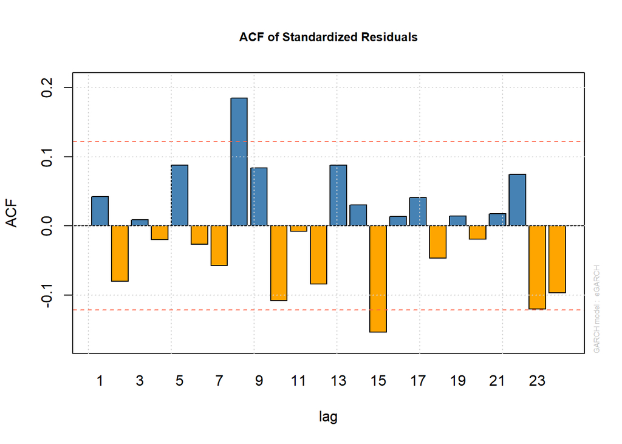

```r
plot(portfolio_OS.ar1egarchmt11, which = 10)
```

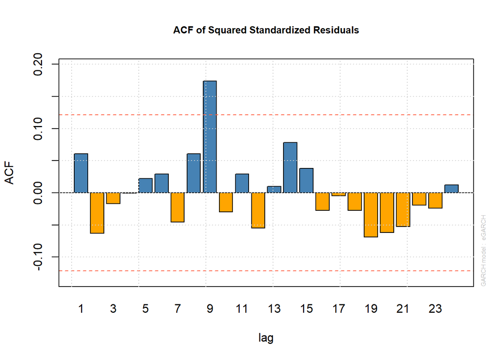

```r
plot(portfolio_OS.ar1egarchmt11, which = 11)
```

Calculating value-at-risk out-of-sample:

```r
portfolio_OS$VaR <- q01 * portfolio_OS.ar1egarchmt11@fit$sigma
```

Plot of returns vs value-at-risk

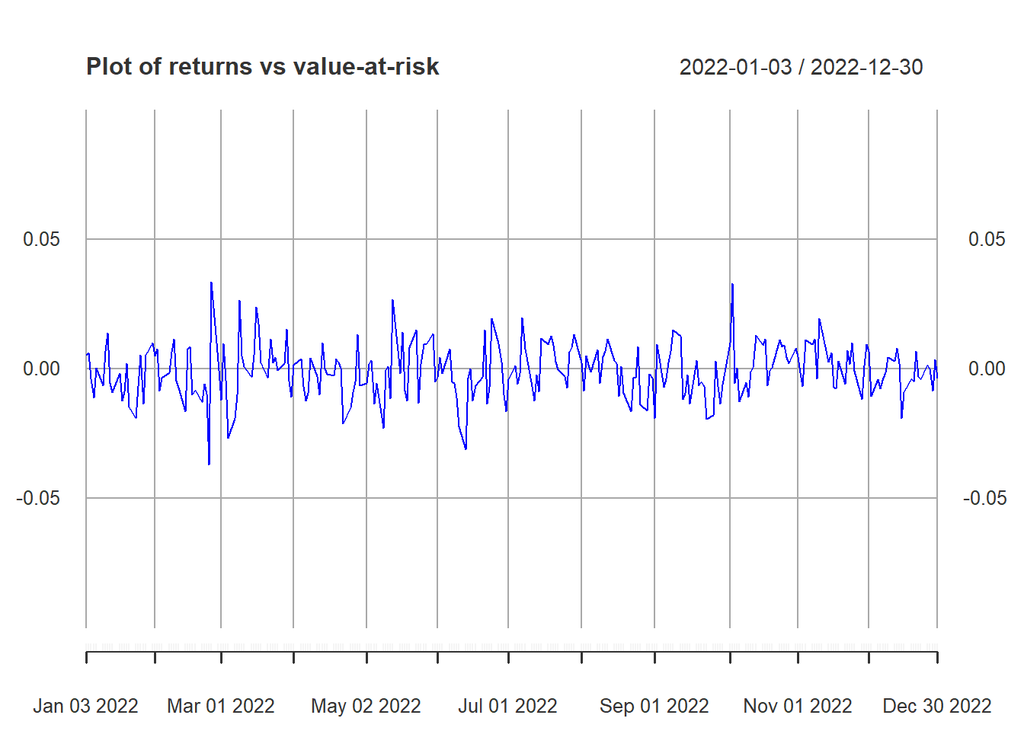

```r
plot(portfolio_OS$PORTFOLIO_r,
     col = "blue", lwd = 1, type = 'l',
     ylim = c(-0.1, 0.1),
     main = "Plot of returns vs value-at-risk")
abline(h = 0, lty = 2)
```

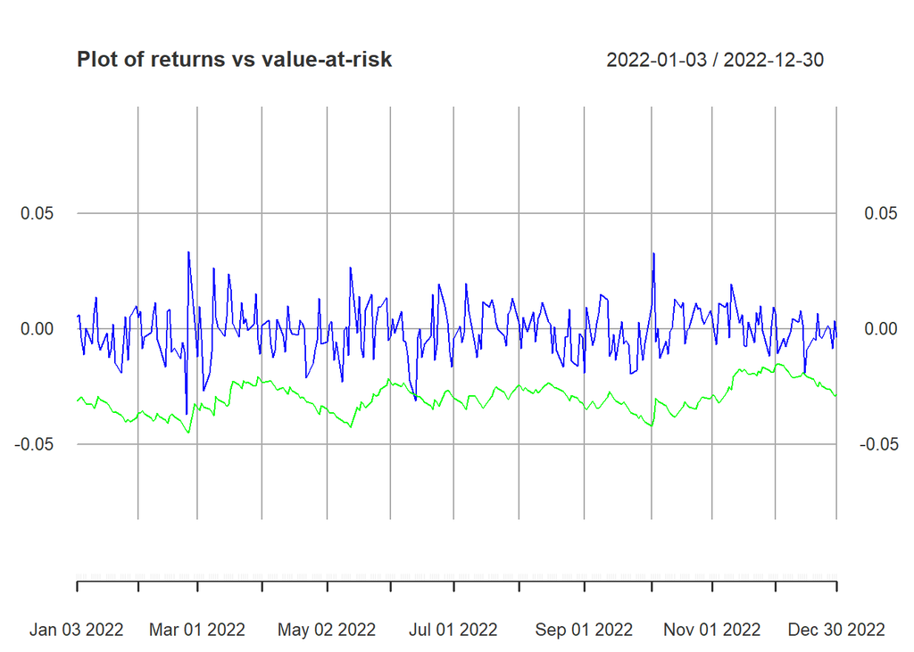

```r
lines(portfolio_OS$VaR, type = 'l', col = "green")
```